# Project 2

Rene Bergeron

Nov 19, 2025

#initialize

```r
library(dplyr)
```

```r
library(ggplot2)
library(stats)
library(ROSE)
library(plotly)
```

# 1. Load Data

In this section, we will load the dataset required for the analysis.

```r
HouseDF <- read.csv("house_15.csv")

str(HouseDF)
```

```
## 'data.frame':    15053 obs. of  23 variables:
##  $ X            : int  1 2 3 4 5 6 7 8 9 10 ...
##  $ id           : num  1.55e+09 2.98e+09 3.53e+09 3.29e+09 3.53e+09 ...
##  $ Year         : int  2014 2014 2014 2014 2014 2014 2014 2015 2014 2015 ...
##  $ Month        : int  10 5 5 6 10 5 5 1 8 5 ...
##  $ Day          : int  21 24 8 27 1 16 16 8 1 12 ...
##  $ day_of_week  : int  2 6 4 5 3 5 5 4 5 2 ...
##  $ price        : num  266500 501000 1310000 355000 655000 ...
##  $ bedrooms     : int  3 2 5 4 3 4 4 5 4 3 ...
##  $ bathrooms    : num  2.25 1 3.25 2.5 1 3 2.5 4 2.5 2.5 ...
##  $ sqft_living  : int  1740 1010 2800 1890 1370 5520 2440 5840 2570 1660 ...
##  $ sqft_lot     : int  5460 4320 3200 7867 5250 8313 4000 11652 9086 1091 ...
##  $ floors       : num  1 1 1.5 2 1 2 2 2 2 3 ...
##  $ waterfront   : int  0 0 0 0 0 0 0 0 0 0 ...
##  $ view         : int  0 0 0 0 0 3 0 1 0 1 ...
##  $ condition    : int  3 5 5 3 3 3 3 3 3 3 ...
##  $ grade        : int  7 7 10 8 7 9 7 11 9 9 ...
##  $ sqft_above   : int  1210 1010 1910 1890 1070 3570 2440 4410 2570 1530 ...
##  $ sqft_basement: int  530 0 890 0 300 1950 0 1430 0 130 ...
##  $ yr_built     : int  1998 1924 1932 1996 1939 2008 2009 1988 1999 2015 ...
##  $ yr_renovated : int  0 0 2002 0 0 0 0 0 0 0 ...
##  $ zipcode      : int  98038 98115 98109 98038 98109 98006 98038 98004 98074 98116 ...
##  $ lat          : num  47.4 47.7 47.6 47.4 47.6 ...
##  $ long         : num  -122 -122 -122 -122 -122 ...
```

*Interpretation*: Once the data is loaded, ensure to examine its structure to ensure everything is in order before moving forward. Explain briefly what each dataset column represents, using layman’s terms where necessary. For example: “This dataset includes customer data such as age, income, and purchase behaviour.”

# 2. Exploratory Data Analysis and Variable explanations

This dataset includes house sale information such as physical information, historical information ## Sales Information:

### -PRICE

This is my target variable. I will construct one regression and one classification model for predictions.

```r
summary(HouseDF$price)
```

```
##    Min. 1st Qu.  Median    Mean 3rd Qu.    Max.
##   75000  322500  450000  538126  640000 7060000
```

That is a pretty large range, definitely some outliers.(Extraordinary Values) Based on domain knowledge, I’m guessing some of these sales were land and some are massive estates. Far from the ordinary sale you might be expecting

First step is checking the viability of removing based on the Statistical method of IQR. This method dicates that anything outside of 1.5 times the middle 50% above or below is considered an outlier. I will apply this method if dataloss are minimal

```r
price_limits <- list(
  quantile(
    HouseDF$price,
    .25) - ( 1.5*IQR(HouseDF$price) ) ,
  quantile(
    HouseDF$price,
    .75) + ( 1.5*IQR(HouseDF$price) )
  )


HouseDFfilter <- HouseDF %>%
  filter(
    price >= price_limits[1] &
      price <= price_limits[2]
  )

outliers_HouseDF <- HouseDF %>%
  filter(
    price >= price_limits[1] &
      price <= price_limits[2]
  )



dataloss <- (nrow(HouseDF) - nrow(HouseDFfilter)) / nrow(HouseDF)
dataloss
```

```
## [1] 0.05321198
```

Dataloss are minimal (barely over 5%), therefore I will continue forward with the outliers removed.

```r
working_HouseDF <- HouseDFfilter
rm(
  HouseDFfilter,
  dataloss,
  outliers_HouseDF
)

summary(working_HouseDF$price)
```

```
##    Min. 1st Qu.  Median    Mean 3rd Qu.    Max.
##   75000  315000  435000  475559  600000 1110000
```

Our minimum price prediction hasn’t changed, but now the model is restricted to houses <= $1,110,000

### -year

Year of Sale

```r
summary(HouseDF$Year)
```

```
##    Min. 1st Qu.  Median    Mean 3rd Qu.    Max.
##    2014    2014    2014    2014    2015    2015
```

```r
t.test(price ~ as.factor(Year), data = HouseDF)
```

```
##
##  Welch Two Sample t-test
##
## data:  price by as.factor(Year)
## t = -0.45846, df = 9899.3, p-value = 0.6466
## alternative hypothesis: true difference in means between group 2014 and group 2015 is not equal to 0
## 95 percent confidence interval:
##  -15007.380   9318.081
## sample estimates:
## mean in group 2014 mean in group 2015
##           537210.7           540055.4
```

This dataset is for sales in 2014 and 2015 The data do not support that the two years had different average prices.

### -month

Month of Sale (January = 1)

Lets explore for popular months:

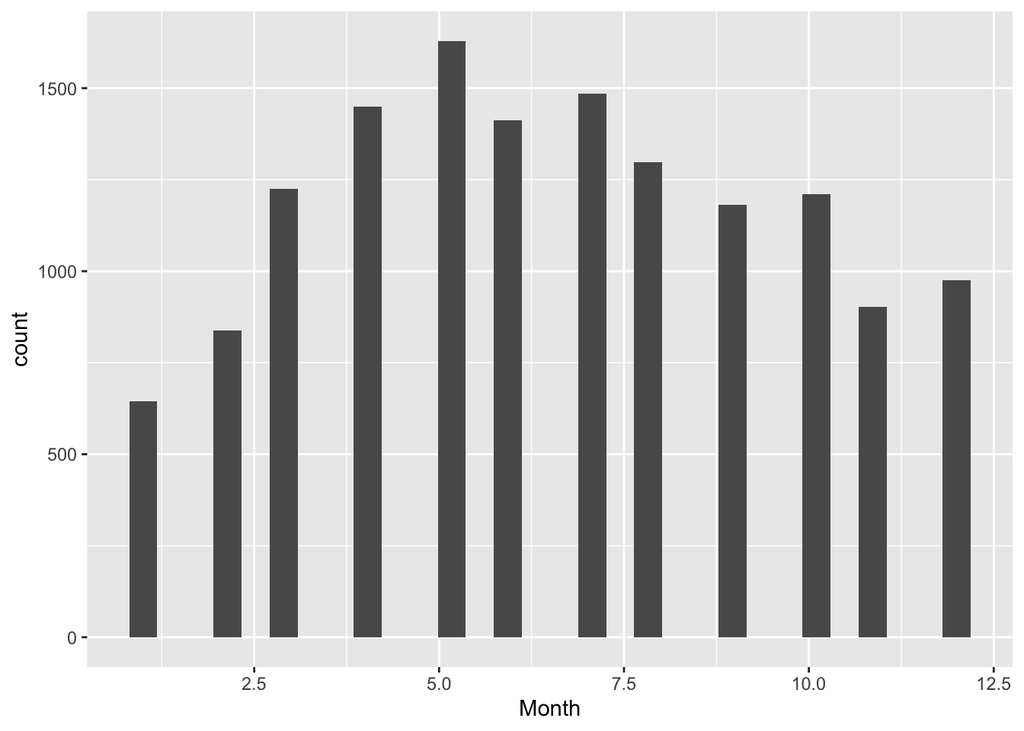

```r
MONTH_histogram <- ggplot(data = working_HouseDF) +
  geom_histogram(aes(x= Month))
MONTH_histogram
```

It sure looks like the peak sales occur between April - August. Sales are higher than the rest of the year. There is also visual growth and decline of volume leading up to and following what I am calling peak season. I am considering a VARIABLE to explain a “peak season price multiplier”

```r
working_HouseDF <- working_HouseDF %>%
  mutate( peak = case_when(Month < 4 |
                             Month > 8 ~ "False",
                           Month >= 4 &
                             Month <= 8 ~ "True"))
str(working_HouseDF$peak)
```

```
##  chr [1:14252] "False" "True" "True" "False" "True" "True" "True" "True" ...
```

```r
working_HouseDF$peak <- as.factor(working_HouseDF$peak)

t.test(price ~ peak,
       data = working_HouseDF)
```

```
##
##  Welch Two Sample t-test
##
## data:  price by peak
## t = -3.7366, df = 14225, p-value = 0.0001873
## alternative hypothesis: true difference in means between group False and group True is not equal to 0
## 95 percent confidence interval:
##  -19739.754  -6155.554
## sample estimates:
## mean in group False  mean in group True
##            468949.5            481897.2
```

The difference in means is not zero, and as I suspected, the average price for houses sold during peak season is higher than those sold during non-peak season. Peak Season Average: $481,897 Non-Peak Season Average: $468,949

I will likely use the peak season variable in my model.

```r
rm(MONTH_histogram)
```

### -day

Day of the Month of the Sale

Same thing, let’s check for trends during the month:

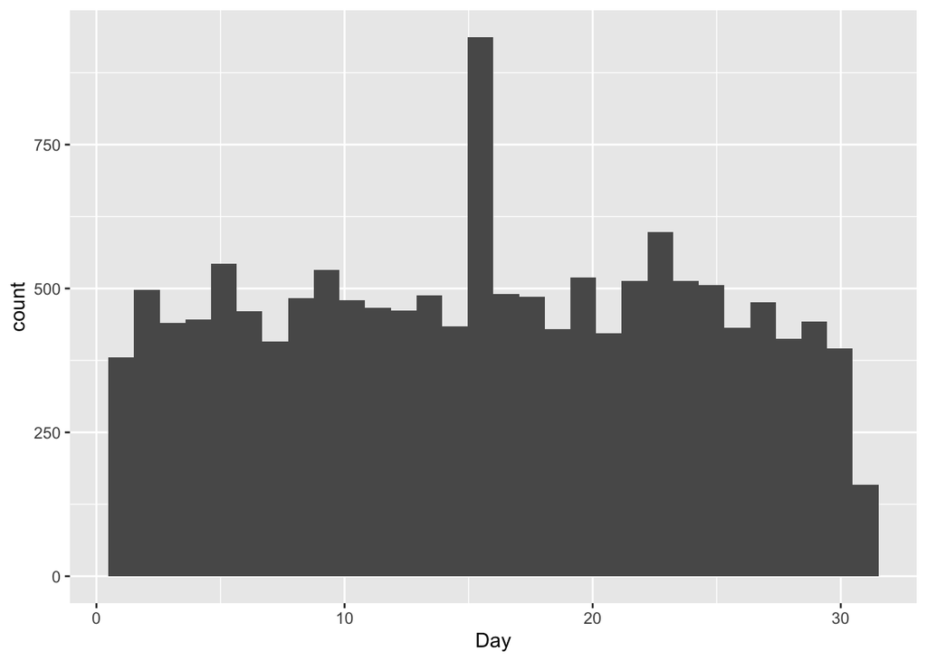

```r
DAY_histogram <- ggplot(data = working_HouseDF) +
  geom_histogram(aes(x= Day))
DAY_histogram
```

There is a noticeable peak around the 15th, but the rest of the data show no discernible pattern

I will likely NOT use dayof the month in my model

```r
rm(DAY_histogram)
```

### -day of week

Day of the Week of the Sale (assuming Sunday = 1)

Checking for trends:

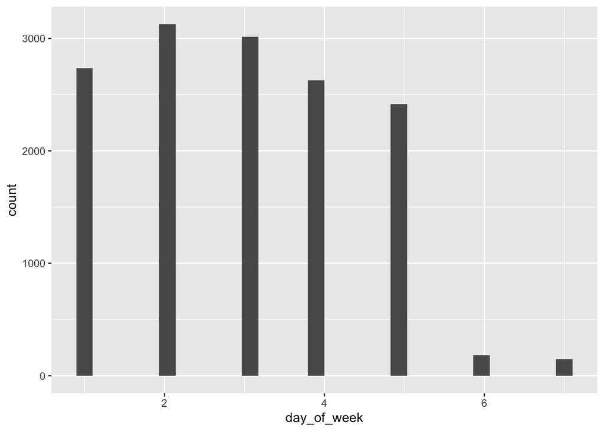

```r
DAYOFWK_histogram <- ggplot(data = working_HouseDF) +
  geom_histogram(aes(x= day_of_week))
DAYOFWK_histogram
```

Very clearly a pattern of few home sales on weekends. Lets see if it affects price:

```r
working_HouseDF <- working_HouseDF %>%
  mutate(
    weekend = case_when(
      day_of_week <= 5 ~ "False",
      day_of_week >5 ~ "True"
    )
  )
str(working_HouseDF$weekend)
```

```
##  chr [1:14252] "False" "True" "False" "False" "False" "False" "False" ...
```

```r
working_HouseDF$weekdend <- as.factor(working_HouseDF$weekend)

t.test(price ~ weekend,
       data = working_HouseDF)
```

```
##
##  Welch Two Sample t-test
##
## data:  price by weekend
## t = -1.4373, df = 346.48, p-value = 0.1515
## alternative hypothesis: true difference in means between group False and group True is not equal to 0
## 95 percent confidence interval:
##  -39695.022   6174.573
## sample estimates:
## mean in group False  mean in group True
##            475168.3            491928.5
```

There are not enough data to support houses sold on the weekend are sold at a different price.

I will likely NOT use day of week in my model

```r
rm(DAYOFWK_histogram)
```

## Physical:

### -bedrooms

number bedrooms

```r
cor(working_HouseDF$price,
    working_HouseDF$bedrooms)
```

```
## [1] 0.2931829
```

There is weak relationship between bedrooms and price

Based on domain knowledge, I will group these houses into clusters based on the number of bedrooms. My knowledge of Seattle living expenses understands that price relationships are not linear and are often stepped at each number of bedrooms. Example, a 1 bedroom to a 2 bedroom with everything else equal would sell for a drastically different amount.

Converting to a factor type because it is can be either a discrete or a continuous variable.

```r
working_HouseDF$bedrooms <- as.factor(working_HouseDF$bedrooms)
summary(working_HouseDF$bedrooms)
```

```
##    0    1    2    3    4    5    6    7    8    9   10   11   33
##    6  146 1900 6699 4404  900  163   25    3    2    2    1    1
```

There is a single data point with 33 bedrooms. It sold for $640,000, so I am assuming this is a typo and it is a 3-bedroom. Since I do not have deeper information about the homesale, I must remove the suspected invalid datapoint.

The data points with 0 bedrooms are likely office spaces as most of them have several floors but did not sell for very high prices. They vary in number of bathrooms, and size, but I will remove them as we are interested in houses, not presumed office spaces. Since it is not considered a house with 0 bedrooms, I will exclude these observations.

```r
working_HouseDF <- working_HouseDF %>%
  mutate( bedrooms = as.character(bedrooms)) %>%
  mutate( bedrooms = as.numeric(bedrooms)) %>%
  filter(
    bedrooms <= 11 &
      bedrooms != 0 ) %>%
  mutate( bedrooms = as.factor(bedrooms) )


summary(working_HouseDF$bedrooms)
```

```
##    1    2    3    4    5    6    7    8    9   10   11
##  146 1900 6699 4404  900  163   25    3    2    2    1
```

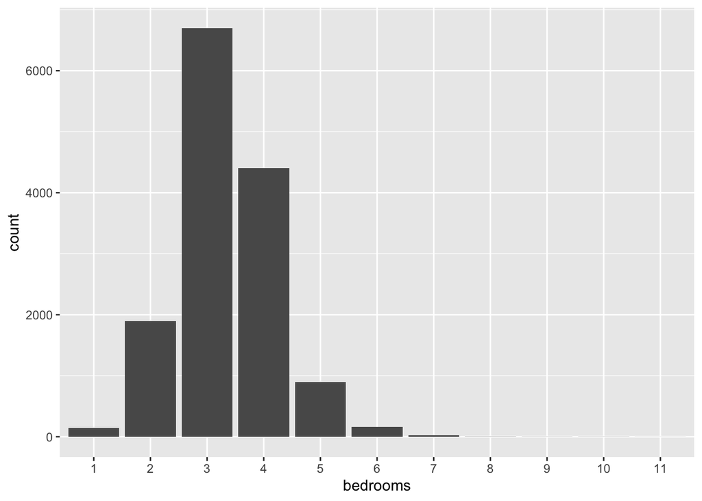

```r
BEDROOMS_bar <- ggplot(data = working_HouseDF) +
  geom_bar(aes(
    x= bedrooms
  ))

BEDROOMS_bar
```

I removed 7 / 14,252 obervations. This is a .04% data loss. Perfectly acceptable and necessary.

```r
working_HouseDF <- working_HouseDF %>%
  mutate( bedrooms = as.character(bedrooms) ) %>%
  mutate( bedrooms = as.numeric(bedrooms) ) %>%
  mutate( bedrooms = case_when(
    bedrooms > 5 ~ "more_than_5",
    .default = as.character(bedrooms)
    )
  ) %>%
  mutate(
    bedrooms = as.factor(bedrooms)
  )
summary(working_HouseDF$bedrooms)
```

```
##           1           2           3           4           5 more_than_5
##         146        1900        6699        4404         900         196
```

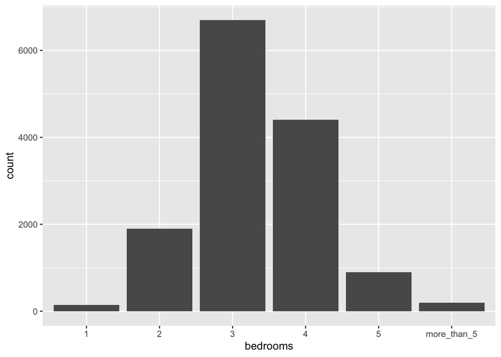

```r
BEDROOMS_bar <- ggplot(data = working_HouseDF) +
  geom_bar(aes(
    x=bedrooms
  ))

BEDROOMS_bar
```

```r
str(working_HouseDF$bedrooms)
```

```
##  Factor w/ 6 levels "1","2","3","4",..: 3 2 4 3 4 4 3 3 4 5 ...
```

Now the data look more normally distributed which make for much more accurate models.

```r
rm(BEDROOMS_bar)
```

Let’s use a statistical test to confirm there is a difference in variance between the bedroom groups.

```r
anova <- aov( price ~ bedrooms ,
              data = working_HouseDF)
summary(anova)
```

```
##                Df    Sum Sq   Mean Sq F value Pr(>F)
## bedrooms        5 6.082e+13 1.216e+13   315.6 <2e-16 ***
## Residuals   14239 5.489e+14 3.855e+10
## ---
## Signif. codes:  0 '***' 0.001 '**' 0.01 '*' 0.05 '.' 0.1 ' ' 1
```

This confirms they have different average prices because the f-test came back almost zero. Basically saying that not all the bedgroom groups have the same average. Next we run another statistical test called “Honest Significant Difference” This goes the next step from the analysis of variance I just ran, and will test pairs of groups to determine which ones are different, this will help me cluster potentially similar groups.

```r
TukeyHSD(anova)
```

```
##   Tukey multiple comparisons of means
##     95% family-wise confidence level
##
## Fit: aov(formula = price ~ bedrooms, data = working_HouseDF)
##
## $bedrooms
##                     diff       lwr       upr     p adj
## 2-1            83467.217  35411.02 131523.41 0.0000111
## 3-1           129410.684  82598.91 176222.46 0.0000000
## 4-1           234341.477 187270.26 281412.69 0.0000000
## 5-1           279004.214 229079.23 328929.20 0.0000000
## more_than_5-1 286139.439 224966.64 347312.24 0.0000000
## 3-2            45943.467  31399.20  60487.74 0.0000000
## 4-2           150874.260 135515.45 166233.06 0.0000000
## 5-2           195536.996 172894.16 218179.83 0.0000000
## more_than_5-2 202672.222 160692.40 244652.04 0.0000000
## 4-3           104930.793  94075.51 115786.08 0.0000000
## 5-3           149593.530 129727.93 169459.13 0.0000000
## more_than_5-3 156728.756 116179.41 197278.10 0.0000000
## 5-4            44662.737  24193.27  65132.21 0.0000000
## more_than_5-4  51797.963  10949.38  92646.55 0.0040974
## more_than_5-5   7135.226 -36971.60  51242.05 0.9974047
```

The only pair that doesn’t have a reliable difference in average price is houses with more than 5 and houses with 5 bedrooms. The results of the Honest Significant Difference leads me to potentially grouping the two.

```r
library(forcats)
summary(working_HouseDF$bedrooms)
```

```
##           1           2           3           4           5 more_than_5
##         146        1900        6699        4404         900         196
```

```r
working_HouseDF <- working_HouseDF %>%
  mutate(
    bedrooms = fct_collapse(
      .f = bedrooms,
      "5_plus" = c("5", "more_than_5")
      )
    )

levels(working_HouseDF$bedrooms)
```

```
## [1] "1"      "2"      "3"      "4"      "5_plus"
```

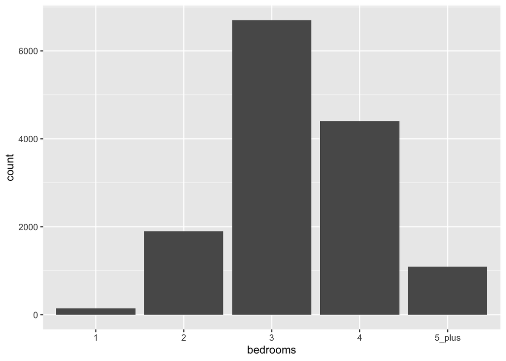

```r
BEDROOMS_bar <- ggplot(working_HouseDF) +
  geom_bar(
    aes(
      x=bedrooms
    )
  )
BEDROOMS_bar
```

```r
anova <- aov(price ~ bedrooms,
             data = working_HouseDF)
summary(anova)
```

```
##                Df    Sum Sq   Mean Sq F value Pr(>F)
## bedrooms        4 6.082e+13 1.520e+13   394.5 <2e-16 ***
## Residuals   14240 5.489e+14 3.854e+10
## ---
## Signif. codes:  0 '***' 0.001 '**' 0.01 '*' 0.05 '.' 0.1 ' ' 1
```

```r
TukeyHSD(anova)
```

```
##   Tukey multiple comparisons of means
##     95% family-wise confidence level
##
## Fit: aov(formula = price ~ bedrooms, data = working_HouseDF)
##
## $bedrooms
##               diff       lwr       upr   p adj
## 2-1       83467.22  37468.87 129465.57 7.4e-06
## 3-1      129410.68  84603.47 174217.90 0.0e+00
## 4-1      234341.48 189285.93 279397.02 0.0e+00
## 5_plus-1 280280.22 233093.29 327467.15 0.0e+00
## 3-2       45943.47  32022.00  59864.93 0.0e+00
## 4-2      150874.26 136173.14 165575.38 0.0e+00
## 5_plus-2 196813.00 176497.32 217128.69 0.0e+00
## 4-3      104930.79  94540.35 115321.24 0.0e+00
## 5_plus-3 150869.54 133417.73 168321.35 0.0e+00
## 5_plus-4  45938.74  27858.88  64018.60 0.0e+00
```

Now we have 5 levels of bedrooms all testing as statistically different average prices.

I will likely use bedrooms in my model

```r
rm(BEDROOMS_bar,
   anova)
```

### -bathrooms

number of bathrooms

```r
cor(working_HouseDF$price,
    working_HouseDF$bathrooms)
```

```
## [1] 0.4541585
```

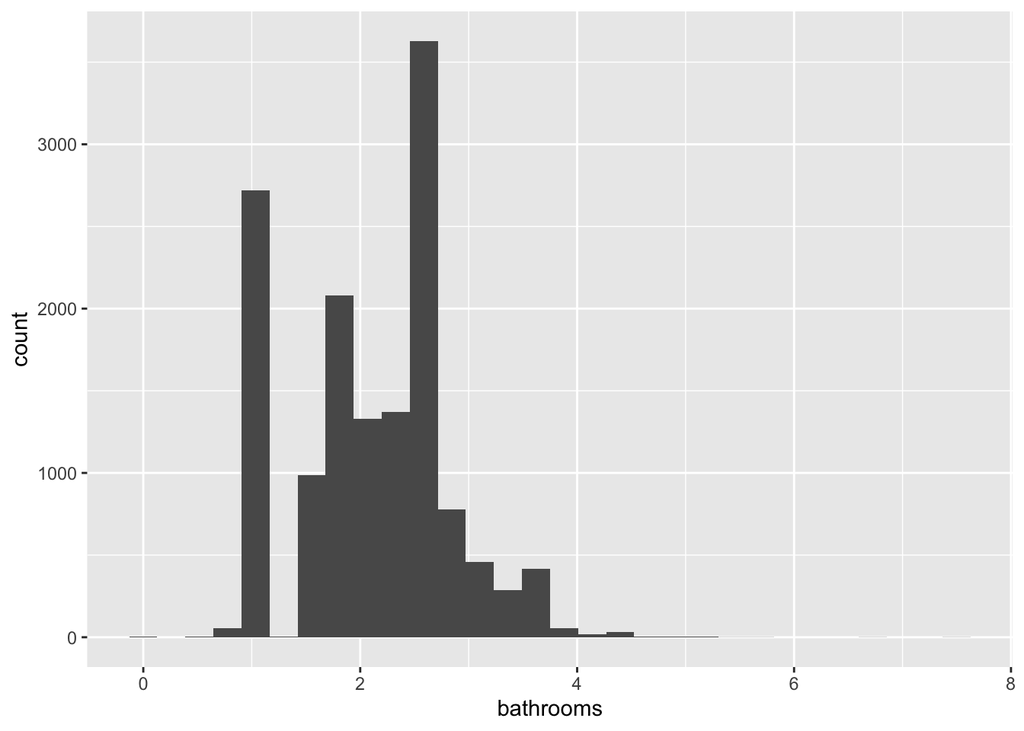

```r
BATHROOMS_histogram <- ggplot(working_HouseDF) +
  geom_histogram(
    aes(
      x= bathrooms
    )
  )
BATHROOMS_histogram
```

There is strong correlation between bathrooms and price.

I will likely use this in my model.

```r
rm(BATHROOMS_histogram)
```

EXPLORE ACCURACY OF SQFT LISTINGS FOR POTENTIAL USAGE OF UPPER v LOWER SQFT INSTEAD OF TOTAL SQUARE FOOTAGE If the data are accurate for above and below square footage, all the above and below should add up to their respective sqft living

### -sqft_living

square footage of the house

### -sqft_above

square footage of above ground floors

###-sqft_basement square footage of the basement

```r
sqftDF <- working_HouseDF %>%
  select(sqft_living,
         sqft_above,
         sqft_basement,
         price) %>%
  rename(sqft_living_listed = sqft_living) %>%
  mutate(sqft_living_calculated = sqft_above + sqft_basement) %>%
  select(sqft_living_listed,
         sqft_living_calculated,
         price) %>%
  mutate(diff_listed_V_calculated = sqft_living_listed - sqft_living_calculated)
summary(sqftDF$diff_listed_V_calculated)
```

```
##    Min. 1st Qu.  Median    Mean 3rd Qu.    Max.
##       0       0       0       0       0       0
```

Good to go (seems fishy haha). The data is perfectly accurate in its division of sqft. This means I may use the above and below sqft to explain price differences.

```r
rm(sqftDF)
```

Now to explore the potential relationship between overall sqft and the price, then I will explore what a ratio of above and below sqft does to the relationship.

```r
cor(working_HouseDF$price , working_HouseDF$sqft_living)
```

```
## [1] 0.6194926
```

A correlation of .62 is extremely high. This strongly suggests using sqft_living as a variable. Now I will check the ratios

```r
sqft_ratios <- working_HouseDF %>%
  mutate( ratio_above = sqft_above / sqft_living)
summary(sqft_ratios$ratio_above)
```

```
##    Min. 1st Qu.  Median    Mean 3rd Qu.    Max.
##  0.3333  0.7367  1.0000  0.8806  1.0000  1.0000
```

This TRANSFORMATION is interpreted as follows: ratio_above = 1 means that the property does not have any basement.

```r
cor(sqft_ratios$price, sqft_ratios$ratio_above)
```

```
## [1] -0.1459337
```

This weak negative correlation between price and ratio above indicates that houses with basements sell for more than those without. Instead of using a ratio to determine the effect, I will add a discrete variable indicating whether or not the property has a basement:

```r
working_HouseDF <- working_HouseDF %>%
  mutate( basement =
            case_when(
              sqft_basement != 0 ~ "True",
              sqft_basement == 0 ~ "False"
            ),
          ratio_above = sqft_above/sqft_living
          )
rm(sqft_ratios)
```

Now we check its significance:

```r
t.test(price ~ basement,
       data = working_HouseDF)
```

```
##
##  Welch Two Sample t-test
##
## data:  price by basement
## t = -20.376, df = 11116, p-value < 2.2e-16
## alternative hypothesis: true difference in means between group False and group True is not equal to 0
## 95 percent confidence interval:
##  -79038.83 -65166.09
## sample estimates:
## mean in group False  mean in group True
##            448709.8            520812.2
```

This confirms my suspicions. Although the correlation between the ratio of above-ground sqft and price is not very strong, the negative correlation there indicates the same inverse relationship indicated here. The difference in average prices for houses with vs without basements indicates the same relationship. Houses in Seattle sell for more if they have a basement.

I may use any combination of living sqft to predict price.

### -sq_ft_lot

square footage of the lot

```r
summary(working_HouseDF$sqft_lot)
```

```
##    Min. 1st Qu.  Median    Mean 3rd Qu.    Max.
##     600    5008    7508   14720   10308 1164794
```

Sheesh, that is a very large range, but luckily all are valid values.

I doubt it, but let’s check IQR:

```r
working_HouseDF_filtered <- working_HouseDF %>%
  filter(sqft_lot >= quantile(sqft_lot,
                              .25) - ( 1.5 * IQR(sqft_lot)
                                       ) &
           sqft_lot <= quantile(sqft_lot,
                                .75) + ( 1.5 * IQR(sqft_lot)
                                         )
         )
```

IQR removed too many outliers, lets see what those outliers might have in common:

```r
working_HouseDF_outliers <- working_HouseDF %>%
  filter(sqft_lot <= quantile(sqft_lot,
                              .25) - ( 1.5 * IQR(sqft_lot)
                                       ) |
           sqft_lot >= quantile(sqft_lot,
                                .75) + ( 1.5 * IQR(sqft_lot)
                                         )
         )
```

I notice no noteable trends or patterns on glancing at the dataframe. To consider using thisvariable in the model, I will perform a log transformation on it. A log transformation will decrease the range of the data and thus decrease the effect of the more extreme values on my prediction.

```r
working_HouseDF <- working_HouseDF %>%
  mutate( LOG_sqft_lot = log(sqft_lot)) %>%
  select(-weekend)

rm(
  working_HouseDF_filtered,
  working_HouseDF_outliers
)
```

This transformation changes our interpretation of the effects of changes to lot size. If using the log transformed variable in the model, changes in lot size must be compared as a percentage change from a similar house.

Similar to the living sqft, I will compare the lot size with correlation to the price:

```r
cor(working_HouseDF$price, working_HouseDF$LOG_sqft_lot)
```

```
## [1] 0.101299
```

This is a very weak correlation at 10% but does suggest that properties with more lot size do sell for more. Lets check something with the lot sizes really quick. I think there may be a relationship between lot sizes and their living sqft. My goal is to determine if properties with land (more lot size than living sqft) sell at a different price rate:

```r
living_V_lot_SQFT <- working_HouseDF %>%
  select(sqft_living,
         sqft_lot,
         price) %>%
  mutate(diff_living_V_lot = sqft_lot - sqft_living)
summary(living_V_lot_SQFT$diff_living_V_lot)
```

```
##    Min. 1st Qu.  Median    Mean 3rd Qu.    Max.
##    -955    3102    5670   12744    8440 1164084
```

```r
nrow(living_V_lot_SQFT$diff_living_V_lot == 0)
```

[output not shown]

I am confused by the negative values and there are no 0 values, so I do not have clear enough information regarding how each of these values are measured/recorded. I will not continue further exploration of the relationship between lot size and living sqft

```r
rm(
  living_V_lot_SQFT
)
```

I will likely NOT use sqft_lot in the model due to its very weak correlation

### -floors

total number of floors in the house

```r
summary(working_HouseDF$floors)
```

```
##    Min. 1st Qu.  Median    Mean 3rd Qu.    Max.
##   1.000   1.000   1.000   1.477   2.000   3.500
```

```r
unique(working_HouseDF$floors)
```

```
## [1] 1.0 2.0 3.0 1.5 2.5 3.5
```

I am unsure what a half floor is in this dataset as it is not specified. The best I can do is treat the variable as continuous even if it may be more advantageous to treat it as discrete.

```r
cor(working_HouseDF$price,
    working_HouseDF$floors)
```

```
## [1] 0.2684011
```

A positive correlation of .27 means there is a weak positive correlation between price and the number of floors. I may use this variable in the model.

### -waterfront

whether the house has a view to the waterfront

```r
t.test(price ~ waterfront,
       data = working_HouseDF)
```

```
##
##  Welch Two Sample t-test
##
## data:  price by waterfront
## t = -5.7212, df = 39.176, p-value = 1.245e-06
## alternative hypothesis: true difference in means between group 0 and group 1 is not equal to 0
## 95 percent confidence interval:
##  -283078.0 -135213.9
## sample estimates:
## mean in group 0 mean in group 1
##        475040.1        684186.1
```

As anticipated, houses with waterfront views sell for much higher prices.

### -view

How many times the house had been viewed at point of data collection.

```r
summary(working_HouseDF$view)
```

```
##    Min. 1st Qu.  Median    Mean 3rd Qu.    Max.
##  0.0000  0.0000  0.0000  0.1667  0.0000  4.0000
```

```r
viewDF <- working_HouseDF %>%
  select(
    view,
    price
  ) %>%
  mutate( first_view_sale = case_when(
    view < 1 ~ "True",
    view >= 1 ~ "False"
  )) %>%
  mutate( first_view_sale = as.factor(first_view_sale))

cor(viewDF$price, viewDF$view)
```

```
## [1] 0.2279548
```

```r
t.test(price ~ first_view_sale,
       data = viewDF)
```

```
##
##  Welch Two Sample t-test
##
## data:  price by first_view_sale
## t = 25.83, df = 1208.8, p-value < 2.2e-16
## alternative hypothesis: true difference in means between group False and group True is not equal to 0
## 95 percent confidence interval:
##  167320.1 194827.4
## sample estimates:
## mean in group False  mean in group True
##            643150.8            462077.0
```

Both the correlation, and the difference in means confirms that more viewers increases the selling price. It’s likely that more viewers leads to more offers.

I will likely use one of these two variables in my model.

```r
rm(viewDF)
```

### -condition

overall condition of the house (1-5, 5 is best)

```r
cor(working_HouseDF$price,
    working_HouseDF$condition)
```

```
## [1] 0.04627623
```

There is extremely weak correlation between condition and price.

I will likely NOT use this variable in my model.

### -grade

King County assessed house condition grade. Higher = better

```r
cor(working_HouseDF$price,
    working_HouseDF$grade)
```

```
## [1] 0.6288808
```

I will likely NOT use this variable in my model.

### -zipcode

zip code of the property Based on domain knowledge, I suspect that houses in Seattle proper (Seattle zip code) sell for higher prices.

```r
Seattle_Zips <- c("98101","98102","98103","98104","98105",
                     "98106","98107","98108","98109","98111",
                     "98112","98113","98114","98115","98116",
                     "98117","98118","98119","98121","98122",
                     "98124","98125","98126","98133","98134",
                     "98136","98144","98146","98154","98161",
                     "98174","98177","98178","98199")

str(Seattle_Zips)
```

```
##  chr [1:34] "98101" "98102" "98103" "98104" "98105" "98106" "98107" "98108" ...
```

```r
working_HouseDF <- working_HouseDF %>%
  mutate( zipcode = as.character(working_HouseDF$zipcode)) %>%
  mutate( Seattle = case_match(
    zipcode,
    Seattle_Zips ~ "True",
    .default = "False"
  )) %>%
  mutate( Seattle = as.factor(Seattle))

str(working_HouseDF)
```

```
## 'data.frame':    14245 obs. of  29 variables:
##  $ X            : int  1 2 4 5 7 9 10 11 12 13 ...
##  $ id           : num  1.55e+09 2.98e+09 3.29e+09 3.53e+09 9.41e+09 ...
##  $ Year         : int  2014 2014 2014 2014 2014 2014 2015 2015 2014 2015 ...
##  $ Month        : int  10 5 6 10 5 8 5 5 9 4 ...
##  $ Day          : int  21 24 27 1 16 1 12 1 10 21 ...
##  $ day_of_week  : int  2 6 5 3 5 5 2 5 3 2 ...
##  $ price        : num  266500 501000 355000 655000 350000 ...
##  $ bedrooms     : Factor w/ 5 levels "1","2","3","4",..: 3 2 4 3 4 4 3 3 4 5 ...
##  $ bathrooms    : num  2.25 1 2.5 1 2.5 2.5 2.5 1 2.5 2.5 ...
##  $ sqft_living  : int  1740 1010 1890 1370 2440 2570 1660 900 1900 3440 ...
##  $ sqft_lot     : int  5460 4320 7867 5250 4000 9086 1091 7576 9428 12350 ...
##  $ floors       : num  1 1 2 1 2 2 3 1 2 1 ...
##  $ waterfront   : int  0 0 0 0 0 0 0 0 0 0 ...
##  $ view         : int  0 0 0 0 0 0 1 0 0 2 ...
##  $ condition    : int  3 5 3 3 3 3 3 4 3 4 ...
##  $ grade        : int  7 7 8 7 7 9 9 6 8 9 ...
##  $ sqft_above   : int  1210 1010 1890 1070 2440 2570 1530 900 1900 1760 ...
##  $ sqft_basement: int  530 0 0 300 0 0 130 0 0 1680 ...
##  $ yr_built     : int  1998 1924 1996 1939 2009 1999 2015 1959 1978 1976 ...
##  $ yr_renovated : int  0 0 0 0 0 0 0 0 0 0 ...
##  $ zipcode      : chr  "98038" "98115" "98038" "98109" ...
##  $ lat          : num  47.4 47.7 47.4 47.6 47.4 ...
##  $ long         : num  -122 -122 -122 -122 -122 ...
##  $ peak         : Factor w/ 2 levels "False","True": 1 2 2 1 2 2 2 2 1 2 ...
##  $ weekdend     : Factor w/ 2 levels "False","True": 1 2 1 1 1 1 1 1 1 1 ...
##  $ basement     : chr  "True" "False" "False" "True" ...
##  $ ratio_above  : num  0.695 1 1 0.781 1 ...
##  $ LOG_sqft_lot : num  8.61 8.37 8.97 8.57 8.29 ...
##  $ Seattle      : Factor w/ 2 levels "False","True": 1 2 1 2 1 1 2 1 1 1 ...
```

Checking hypothesis:

```r
t.test(price ~ Seattle,
       data = working_HouseDF)
```

```
##
##  Welch Two Sample t-test
##
## data:  price by Seattle
## t = -14.275, df = 10430, p-value < 2.2e-16
## alternative hypothesis: true difference in means between group False and group True is not equal to 0
## 95 percent confidence interval:
##  -57860.11 -43888.03
## sample estimates:
## mean in group False  mean in group True
##            458120.5            508994.6
```

My hypothesis is true, Seattle houses have a higher average sale price.

I will likely use this variable instead of zipcode.

### -lat

Latitude coordinate of the house This is another location based indicator, but would not provide meaningful analysis

### -long

longitude coordinate of the house This is another location based indicator, but would not provide meaningful analysis.

I will NOT use zip, lat, or long in my model

Historical:

### -yr_built

year the house was built

```r
summary(working_HouseDF$yr_built)
```

```
##    Min. 1st Qu.  Median    Mean 3rd Qu.    Max.
##    1900    1951    1974    1971    1996    2015
```

```r
cor(working_HouseDF$price,
    working_HouseDF$yr_built)
```

```
## [1] 0.05918879
```

There is very weak correlation between year built and price.

I will likely NOT use yr_built in my model.

### -yr_renovated

year the house was renovated

```r
summary(working_HouseDF$yr_renovated)
```

```
##    Min. 1st Qu.  Median    Mean 3rd Qu.    Max.
##     0.0     0.0     0.0    75.9     0.0  2015.0
```

```r
cor(working_HouseDF$price,
    working_HouseDF$yr_renovated)
```

```
## [1] 0.08049369
```

There is slightly stronger correlation between price and yr_renovated

I notice the majority of houses have not had renovations as indicated by a 0. It may be useful to treat this as a dummy variable as to whether or not the house has had a renovation.

```r
RenovatedDF <- working_HouseDF %>%
  select(yr_renovated,
         price) %>%
  mutate( renovated = case_when(
    yr_renovated != 0 ~ "True",
    .default = "False"
  )) %>%
  mutate( renovated = as.factor(renovated))

t.test( price ~ renovated,
        data = RenovatedDF)
```

```
##
##  Welch Two Sample t-test
##
## data:  price by renovated
## t = -8.3441, df = 573.17, p-value = 5.377e-16
## alternative hypothesis: true difference in means between group False and group True is not equal to 0
## 95 percent confidence interval:
##  -106902.65  -66164.67
## sample estimates:
## mean in group False  mean in group True
##            472334.9            558868.5
```

This concludes that houses with renovations sell for higher prices.

I may use this variable in my model.

```r
rm(RenovatedDF)
```

# 3. Data Preprocessing

## Transformations

Perform data cleaning, such as handling missing values, transforming variables, or creating new features.

### First, narrow down the dataset into just the variables I may use:

```r
working_HouseDF <- working_HouseDF %>%
  select(bedrooms,
         bathrooms,
         sqft_living,
         sqft_above,
         sqft_basement,
         sqft_lot,
         floors,
         waterfront,
         view,
         zipcode,
         yr_built,
         yr_renovated,
         Month,
         Year,
         price)
str(working_HouseDF)
```

```
## 'data.frame':    14245 obs. of  15 variables:
##  $ bedrooms     : Factor w/ 5 levels "1","2","3","4",..: 3 2 4 3 4 4 3 3 4 5 ...
##  $ bathrooms    : num  2.25 1 2.5 1 2.5 2.5 2.5 1 2.5 2.5 ...
##  $ sqft_living  : int  1740 1010 1890 1370 2440 2570 1660 900 1900 3440 ...
##  $ sqft_above   : int  1210 1010 1890 1070 2440 2570 1530 900 1900 1760 ...
##  $ sqft_basement: int  530 0 0 300 0 0 130 0 0 1680 ...
##  $ sqft_lot     : int  5460 4320 7867 5250 4000 9086 1091 7576 9428 12350 ...
##  $ floors       : num  1 1 2 1 2 2 3 1 2 1 ...
##  $ waterfront   : int  0 0 0 0 0 0 0 0 0 0 ...
##  $ view         : int  0 0 0 0 0 0 1 0 0 2 ...
##  $ zipcode      : chr  "98038" "98115" "98038" "98109" ...
##  $ yr_built     : int  1998 1924 1996 1939 2009 1999 2015 1959 1978 1976 ...
##  $ yr_renovated : int  0 0 0 0 0 0 0 0 0 0 ...
##  $ Month        : int  10 5 6 10 5 8 5 5 9 4 ...
##  $ Year         : int  2014 2014 2014 2014 2014 2014 2015 2015 2014 2015 ...
##  $ price        : num  266500 501000 355000 655000 350000 ...
```

The variable narrowing and transformations up to this point have been discussed in the exploratory data analysis.

### Redoing some earlier transformations for the model.

```r
working_HouseDF <- working_HouseDF %>%
  mutate(
    ratio_sqft_above = sqft_above / sqft_living ,
    peak_volume_season = case_when(
      Month < 4 |
        Month > 8 ~ "False" ,
      .default = "True"
      ),
    first_view_sale = case_when(
      view < 1 ~ "True",
      .default = "False"
      ),
    Seattle = case_match(
      zipcode,
      Seattle_Zips ~ "True",
      .default = "False"
      ),
    basement = case_when(
      sqft_basement != 0 ~ "True",
      .default = "False"
    ),
    log_sqft_lot = log(sqft_lot),
    renovated = case_when(
      yr_renovated !=0 ~ "True",
      .default = "False"
    )
    ) %>%
  mutate(
    across(
      c(peak_volume_season, first_view_sale, Seattle, basement, waterfront,
        zipcode, renovated),
      as.factor
    )
  ) %>%
  mutate(
    across(
      c(bathrooms, sqft_living, sqft_above, sqft_basement,
        sqft_lot, floors, view, yr_built, yr_renovated,
        Month, Year, price, log_sqft_lot),
      as.numeric  )
    )

str(working_HouseDF)
```

```
## 'data.frame':    14245 obs. of  22 variables:
##  $ bedrooms          : Factor w/ 5 levels "1","2","3","4",..: 3 2 4 3 4 4 3 3 4 5 ...
##  $ bathrooms         : num  2.25 1 2.5 1 2.5 2.5 2.5 1 2.5 2.5 ...
##  $ sqft_living       : num  1740 1010 1890 1370 2440 2570 1660 900 1900 3440 ...
##  $ sqft_above        : num  1210 1010 1890 1070 2440 2570 1530 900 1900 1760 ...
##  $ sqft_basement     : num  530 0 0 300 0 0 130 0 0 1680 ...
##  $ sqft_lot          : num  5460 4320 7867 5250 4000 ...
##  $ floors            : num  1 1 2 1 2 2 3 1 2 1 ...
##  $ waterfront        : Factor w/ 2 levels "0","1": 1 1 1 1 1 1 1 1 1 1 ...
##  $ view              : num  0 0 0 0 0 0 1 0 0 2 ...
##  $ zipcode           : Factor w/ 70 levels "98001","98002",..: 24 50 24 48 24 38 51 2 17 3 ...
##  $ yr_built          : num  1998 1924 1996 1939 2009 ...
##  $ yr_renovated      : num  0 0 0 0 0 0 0 0 0 0 ...
##  $ Month             : num  10 5 6 10 5 8 5 5 9 4 ...
##  $ Year              : num  2014 2014 2014 2014 2014 ...
##  $ price             : num  266500 501000 355000 655000 350000 ...
##  $ ratio_sqft_above  : num  0.695 1 1 0.781 1 ...
##  $ peak_volume_season: Factor w/ 2 levels "False","True": 1 2 2 1 2 2 2 2 1 2 ...
##  $ first_view_sale   : Factor w/ 2 levels "False","True": 2 2 2 2 2 2 1 2 2 1 ...
##  $ Seattle           : Factor w/ 2 levels "False","True": 1 2 1 2 1 1 2 1 1 1 ...
##  $ basement          : Factor w/ 2 levels "False","True": 2 1 1 2 1 1 2 1 1 2 ...
##  $ log_sqft_lot      : num  8.61 8.37 8.97 8.57 8.29 ...
##  $ renovated         : Factor w/ 2 levels "False","True": 1 1 1 1 1 1 1 1 1 1 ...
```

### reselect in better order based on correlation with price at the end

```r
cormat <- working_HouseDF%>%
  select(where(is.numeric))
cor(cormat)
```

```
##                    bathrooms sqft_living    sqft_above sqft_basement
## bathrooms         1.00000000  0.71660176  0.6426018056   0.212115070
## sqft_living       0.71660176  1.00000000  0.8535038130   0.372978054
## sqft_above        0.64260181  0.85350381  1.0000000000  -0.165146883
## sqft_basement     0.21211507  0.37297805 -0.1651468826   1.000000000
## sqft_lot          0.07157958  0.16806497  0.1696774970   0.015973686
## floors            0.50592350  0.34337867  0.5320873236  -0.297509582
## view              0.09308874  0.16290352  0.0588039438   0.203624555
## yr_built          0.54040697  0.35475148  0.4636403477  -0.154108277
## yr_renovated      0.02310057  0.02117883  0.0005616078   0.039085522
## Month             0.01056774  0.01629346  0.0138117197   0.006245926
## Year             -0.03590258 -0.03575367 -0.0299989621  -0.014255782
## price             0.45415846  0.61949256  0.5244403663   0.238711689
## ratio_sqft_above -0.10951693 -0.20694357  0.3079111288  -0.939948064
## log_sqft_lot      0.04990766  0.31841138  0.2930195382   0.080915487
##                      sqft_lot       floors         view     yr_built
## bathrooms         0.071579584  0.505923503  0.093088744  0.540406966
## sqft_living       0.168064973  0.343378673  0.162903518  0.354751478
## sqft_above        0.169677497  0.532087324  0.058803944  0.463640348
## sqft_basement     0.015973686 -0.297509582  0.203624555 -0.154108277
## sqft_lot          1.000000000 -0.015930528  0.077034388  0.050292494
## floors           -0.015930528  1.000000000 -0.020121388  0.509377102
## view              0.077034388 -0.020121388  1.000000000 -0.067064486
## yr_built          0.050292494  0.509377102 -0.067064486  1.000000000
## yr_renovated      0.007148787 -0.001994287  0.061052097 -0.222038838
## Month             0.004823156  0.017485746  0.002835809 -0.004054758
## Year             -0.003055750 -0.028742448 -0.002220498 -0.005411277
## price             0.097399539  0.268401075  0.227954752  0.059188789
## ratio_sqft_above  0.025501487  0.360862966 -0.151307302  0.203239177
## log_sqft_lot      0.653313535 -0.257842638  0.095938737 -0.022977510
##                   yr_renovated        Month         Year        price
## bathrooms         0.0231005664  0.010567738 -0.035902584  0.454158460
## sqft_living       0.0211788309  0.016293462 -0.035753673  0.619492560
## sqft_above        0.0005616078  0.013811720 -0.029998962  0.524440366
## sqft_basement     0.0390855221  0.006245926 -0.014255782  0.238711689
## sqft_lot          0.0071487867  0.004823156 -0.003055750  0.097399539
## floors           -0.0019942872  0.017485746 -0.028742448  0.268401075
## view              0.0610520969  0.002835809 -0.002220498  0.227954752
## yr_built         -0.2220388384 -0.004054758 -0.005411277  0.059188789
## yr_renovated      1.0000000000  0.017375681 -0.027535431  0.080493686
## Month             0.0173756812  1.000000000 -0.780761417 -0.010956941
## Year             -0.0275354308 -0.780761417  1.000000000  0.005657005
## price             0.0804936865 -0.010956941  0.005657005  1.000000000
## ratio_sqft_above -0.0306140725 -0.002505337  0.007674475 -0.145933721
## log_sqft_lot      0.0163728025  0.001720604 -0.010875076  0.101298975
##                  ratio_sqft_above log_sqft_lot
## bathrooms            -0.109516932  0.049907661
## sqft_living          -0.206943571  0.318411385
## sqft_above            0.307911129  0.293019538
## sqft_basement        -0.939948064  0.080915487
## sqft_lot              0.025501487  0.653313535
## floors                0.360862966 -0.257842638
## view                 -0.151307302  0.095938737
## yr_built              0.203239177 -0.022977510
## yr_renovated         -0.030614073  0.016372803
## Month                -0.002505337  0.001720604
## Year                  0.007674475 -0.010875076
## price                -0.145933721  0.101298975
## ratio_sqft_above      1.000000000 -0.005904579
## log_sqft_lot         -0.005904579  1.000000000
```

*Interpretation*: My cleaning, manipulations, and translations are described alongside their manipulations

## Select variables.

```r
working_HouseDF <- working_HouseDF %>%
  select(sqft_living, sqft_above, bathrooms, floors,
         sqft_basement, view, ratio_sqft_above, log_sqft_lot, bedrooms,
         renovated, waterfront, peak_volume_season, first_view_sale, Seattle,
         basement,  price
         )
str(working_HouseDF)
```

```
## 'data.frame':    14245 obs. of  16 variables:
##  $ sqft_living       : num  1740 1010 1890 1370 2440 2570 1660 900 1900 3440 ...
##  $ sqft_above        : num  1210 1010 1890 1070 2440 2570 1530 900 1900 1760 ...
##  $ bathrooms         : num  2.25 1 2.5 1 2.5 2.5 2.5 1 2.5 2.5 ...
##  $ floors            : num  1 1 2 1 2 2 3 1 2 1 ...
##  $ sqft_basement     : num  530 0 0 300 0 0 130 0 0 1680 ...
##  $ view              : num  0 0 0 0 0 0 1 0 0 2 ...
##  $ ratio_sqft_above  : num  0.695 1 1 0.781 1 ...
##  $ log_sqft_lot      : num  8.61 8.37 8.97 8.57 8.29 ...
##  $ bedrooms          : Factor w/ 5 levels "1","2","3","4",..: 3 2 4 3 4 4 3 3 4 5 ...
##  $ renovated         : Factor w/ 2 levels "False","True": 1 1 1 1 1 1 1 1 1 1 ...
##  $ waterfront        : Factor w/ 2 levels "0","1": 1 1 1 1 1 1 1 1 1 1 ...
##  $ peak_volume_season: Factor w/ 2 levels "False","True": 1 2 2 1 2 2 2 2 1 2 ...
##  $ first_view_sale   : Factor w/ 2 levels "False","True": 2 2 2 2 2 2 1 2 2 1 ...
##  $ Seattle           : Factor w/ 2 levels "False","True": 1 2 1 2 1 1 2 1 1 1 ...
##  $ basement          : Factor w/ 2 levels "False","True": 2 1 1 2 1 1 2 1 1 2 ...
##  $ price             : num  266500 501000 355000 655000 350000 ...
```

```r
rm(cormat,
   HouseDF)
```

# 4. Training-Validation Split

Split the data into training and validation sets to evaluate the model’s performance.

```r
library(rsample)
set.seed(42)
Split_House_DF <- initial_split(working_HouseDF,
                         prop = 7/10)

TrainData <- training(Split_House_DF)

ValiData <- testing(Split_House_DF)

rm(Split_House_DF)
```

*Interpretation*: I am splitting the data to train have data to compare the performance of our model too. One section(larger portion) will be used to train the model and create the best linear model I can. The smaller section will then be used to compare the accuracy of our model to. Basically, I tell the model to learn the patterns that lead to the answers its given. I then test whether those patterns hold true to unseen data. By having the answers already, I can see how close the model gets and test the models biases if it has any. Normally ratios of 80/20(80% of data are used for training, 20% for validating), 70/30, and 60/40. The smalller the dataset, the more you need to partition to validation data to ensure you have enough data to test on. I choose to use 70/30 for my split because the dataset is fairly large.

# 5. Model 1 Linear Regression Model

## 5.1 Model 1 Predictions

Train Model 1 and generate predictions on the validation data.

```r
Reg_model_1 <- lm(
  formula = price ~
    . - sqft_living - sqft_above - sqft_basement - basement - first_view_sale ,
  data = TrainData
)
summary(Reg_model_1)
```

```
##
## Call:
## lm(formula = price ~ . - sqft_living - sqft_above - sqft_basement -
##     basement - first_view_sale, data = TrainData)
##
## Residuals:
##     Min      1Q  Median      3Q     Max
## -677265 -125041  -23031   99240  735820
##
## Coefficients:
##                        Estimate Std. Error t value Pr(>|t|)
## (Intercept)             -313892      29794 -10.536  < 2e-16 ***
## bathrooms                 99338       3447  28.817  < 2e-16 ***
## floors                    61457       4567  13.456  < 2e-16 ***
## view                      46221       2877  16.067  < 2e-16 ***
## ratio_sqft_above         -86754      12347  -7.026 2.26e-12 ***
## log_sqft_lot              49958       2288  21.837  < 2e-16 ***
## bedrooms2                 53302      17255   3.089  0.00201 **
## bedrooms3                 52273      16992   3.076  0.00210 **
## bedrooms4                100717      17323   5.814 6.28e-09 ***
## bedrooms5_plus            96218      18372   5.237 1.66e-07 ***
## renovatedTrue             35010       8823   3.968 7.29e-05 ***
## waterfront1                7912      34099   0.232  0.81653
## peak_volume_seasonTrue     7403       3388   2.185  0.02893 *
## SeattleTrue              117700       4382  26.859  < 2e-16 ***
## ---
## Signif. codes:  0 '***' 0.001 '**' 0.01 '*' 0.05 '.' 0.1 ' ' 1
##
## Residual standard error: 169000 on 9957 degrees of freedom
## Multiple R-squared:  0.3283, Adjusted R-squared:  0.3274
## F-statistic: 374.3 on 13 and 9957 DF,  p-value: < 2.2e-16
```

This model has great efficiency with all its coefficients except whether the house has a waterfront view. This model is not great at predicting as it can only explain 33% of the variance in price based on the variables. In other words, this model kinda sucks, but the biggest problem right now is that waterfront is not a reliable predictor.

```r
rm(Reg_model_1)

Reg_model_2 <- lm(
  formula = price ~
    . - sqft_living - sqft_above - sqft_basement - basement - first_view_sale -
    waterfront,
  data = TrainData
)
summary(Reg_model_2)
```

```
##
## Call:
## lm(formula = price ~ . - sqft_living - sqft_above - sqft_basement -
##     basement - first_view_sale - waterfront, data = TrainData)
##
## Residuals:
##     Min      1Q  Median      3Q     Max
## -677132 -125010  -23070   99218  735789
##
## Coefficients:
##                        Estimate Std. Error t value Pr(>|t|)
## (Intercept)             -313885      29792 -10.536  < 2e-16 ***
## bathrooms                 99321       3446  28.820  < 2e-16 ***
## floors                    61491       4565  13.470  < 2e-16 ***
## view                      46407       2763  16.798  < 2e-16 ***
## ratio_sqft_above         -86783      12346  -7.029 2.21e-12 ***
## log_sqft_lot              49966       2287  21.844  < 2e-16 ***
## bedrooms2                 53274      17254   3.088  0.00202 **
## bedrooms3                 52211      16990   3.073  0.00212 **
## bedrooms4                100628      17318   5.811 6.41e-09 ***
## bedrooms5_plus            96147      18368   5.234 1.69e-07 ***
## renovatedTrue             35109       8812   3.984 6.82e-05 ***
## peak_volume_seasonTrue     7403       3388   2.185  0.02893 *
## SeattleTrue              117649       4376  26.882  < 2e-16 ***
## ---
## Signif. codes:  0 '***' 0.001 '**' 0.01 '*' 0.05 '.' 0.1 ' ' 1
##
## Residual standard error: 169000 on 9958 degrees of freedom
## Multiple R-squared:  0.3283, Adjusted R-squared:  0.3275
## F-statistic: 405.5 on 12 and 9958 DF,  p-value: < 2.2e-16
```

This model has fully efficient variables, but is still crappy at predicting price.

```r
rm(Reg_model_2)

Reg_model_3 <- lm(
  formula = price ~
    .  - sqft_above - ratio_sqft_above - first_view_sale -
    waterfront,
  data = TrainData
)
summary(Reg_model_3)
```

```
##
## Call:
## lm(formula = price ~ . - sqft_above - ratio_sqft_above - first_view_sale -
##     waterfront, data = TrainData)
##
## Residuals:
##     Min      1Q  Median      3Q     Max
## -532612 -102956  -14944   92332  769339
##
## Coefficients:
##                          Estimate Std. Error t value Pr(>|t|)
## (Intercept)             -7874.835  25846.459  -0.305  0.76062
## sqft_living               200.571      3.685  54.428  < 2e-16 ***
## bathrooms                9197.692   3418.064   2.691  0.00714 **
## floors                   -964.633   4150.353  -0.232  0.81622
## sqft_basement             -88.524      8.003 -11.061  < 2e-16 ***
## view                    32783.603   2441.858  13.426  < 2e-16 ***
## log_sqft_lot             4930.901   2168.026   2.274  0.02296 *
## bedrooms2                7476.065  15097.273   0.495  0.62047
## bedrooms3              -16778.143  14892.633  -1.127  0.25994
## bedrooms4              -31735.663  15300.063  -2.074  0.03808 *
## bedrooms5_plus         -65860.049  16301.014  -4.040 5.38e-05 ***
## renovatedTrue           36769.162   7698.376   4.776 1.81e-06 ***
## peak_volume_seasonTrue   8665.599   2959.857   2.928  0.00342 **
## SeattleTrue            125022.525   3847.956  32.491  < 2e-16 ***
## basementTrue            47115.612   6014.196   7.834 5.21e-15 ***
## ---
## Signif. codes:  0 '***' 0.001 '**' 0.01 '*' 0.05 '.' 0.1 ' ' 1
##
## Residual standard error: 147700 on 9956 degrees of freedom
## Multiple R-squared:  0.4876, Adjusted R-squared:  0.4869
## F-statistic: 676.7 on 14 and 9956 DF,  p-value: < 2.2e-16
```

A good bit better at predicting, but I know I can get more accurate. And I need to reconsider some of the inefficient variables. Floors is the worst.

```r
rm(Reg_model_3)

Reg_model_4 <- lm(
  formula = price ~
    .  - sqft_above - ratio_sqft_above - first_view_sale - waterfront - floors,
  data = TrainData
)
summary(Reg_model_4)
```

```
##
## Call:
## lm(formula = price ~ . - sqft_above - ratio_sqft_above - first_view_sale -
##     waterfront - floors, data = TrainData)
##
## Residuals:
##     Min      1Q  Median      3Q     Max
## -530837 -102836  -15022   92534  769403
##
## Coefficients:
##                          Estimate Std. Error t value Pr(>|t|)
## (Intercept)            -10038.467  24110.691  -0.416  0.67716
## sqft_living               200.297      3.492  57.354  < 2e-16 ***
## bathrooms                8916.946   3197.362   2.789  0.00530 **
## sqft_basement             -87.969      7.638 -11.518  < 2e-16 ***
## view                    32778.251   2441.634  13.425  < 2e-16 ***
## log_sqft_lot             5112.915   2021.552   2.529  0.01145 *
## bedrooms2                7541.049  15093.966   0.500  0.61736
## bedrooms3              -16706.002  14888.691  -1.122  0.26186
## bedrooms4              -31628.693  15292.413  -2.068  0.03864 *
## bedrooms5_plus         -65655.020  16276.355  -4.034 5.53e-05 ***
## renovatedTrue           36773.141   7697.991   4.777 1.80e-06 ***
## peak_volume_seasonTrue   8653.291   2959.243   2.924  0.00346 **
## SeattleTrue            124903.113   3813.322  32.754  < 2e-16 ***
## basementTrue            47194.555   6004.312   7.860 4.24e-15 ***
## ---
## Signif. codes:  0 '***' 0.001 '**' 0.01 '*' 0.05 '.' 0.1 ' ' 1
##
## Residual standard error: 147600 on 9957 degrees of freedom
## Multiple R-squared:  0.4876, Adjusted R-squared:  0.4869
## F-statistic: 728.8 on 13 and 9957 DF,  p-value: < 2.2e-16
```

This model is no more accurate than the one with floors. I am keeping floors out as it may cause overfitting and it didnt affect the models accuracy. I am now going to simplify the model as much as I can to decrease overfitting and maintain as much accuracy as possible.

```r
rm(Reg_model_4)

Reg_model_5 <- lm(
  formula = price ~
    sqft_living + bathrooms + view +
    ratio_sqft_above + bedrooms + renovated +
    peak_volume_season + Seattle ,
  data = TrainData
)
summary(Reg_model_5)
```

```
##
## Call:
## lm(formula = price ~ sqft_living + bathrooms + view + ratio_sqft_above +
##     bedrooms + renovated + peak_volume_season + Seattle, data = TrainData)
##
## Residuals:
##     Min      1Q  Median      3Q     Max
## -525750 -103656  -14579   92576  764010
##
## Coefficients:
##                          Estimate Std. Error t value Pr(>|t|)
## (Intercept)            -30444.025  18038.051  -1.688 0.091487 .
## sqft_living               192.970      3.182  60.645  < 2e-16 ***
## bathrooms               10844.587   3033.023   3.576 0.000351 ***
## view                    31437.452   2427.831  12.949  < 2e-16 ***
## ratio_sqft_above        73487.024   9378.174   7.836 5.13e-15 ***
## bedrooms2               12780.259  15140.399   0.844 0.398625
## bedrooms3               -8852.387  14938.079  -0.593 0.553459
## bedrooms4              -24548.038  15350.880  -1.599 0.109824
## bedrooms5_plus         -64370.590  16348.632  -3.937 8.29e-05 ***
## renovatedTrue           36387.369   7713.117   4.718 2.42e-06 ***
## peak_volume_seasonTrue   8891.250   2971.328   2.992 0.002775 **
## SeattleTrue            125322.230   3432.875  36.506  < 2e-16 ***
## ---
## Signif. codes:  0 '***' 0.001 '**' 0.01 '*' 0.05 '.' 0.1 ' ' 1
##
## Residual standard error: 148300 on 9959 degrees of freedom
## Multiple R-squared:  0.4832, Adjusted R-squared:  0.4827
## F-statistic: 846.6 on 11 and 9959 DF,  p-value: < 2.2e-16
```

Let’s check the linear regression for validity:

```r
library(lmtest)
library(gvlma)
library(stats)
library(car)
multico <- vif(Reg_model_5)
multico
```

```
##                        GVIF Df GVIF^(1/(2*Df))
## sqft_living        2.656310  1        1.629819
## bathrooms          2.093189  1        1.446786
## view               1.062974  1        1.031006
## ratio_sqft_above   1.159551  1        1.076825
## bedrooms           1.738321  4        1.071559
## renovated          1.014353  1        1.007151
## peak_volume_season 1.000981  1        1.000491
## Seattle            1.210759  1        1.100345
```

```r
heteroSk <- bptest(Reg_model_5)
heteroSk
```

```
##
##  studentized Breusch-Pagan test
##
## data:  Reg_model_5
## BP = 425.26, df = 11, p-value < 2.2e-16
```

There is likely heteroskedasticity in the model as indicated by the very low p-value This will account for and correct heteroskedasticity.

```r
model_of_weights <- lm(abs(Reg_model_5$residuals) ~ Reg_model_5$fitted.values)

weight <- 1/(model_of_weights$fitted.values)^2

Reg_model_5_weighted <- lm(
  formula = price ~
    sqft_living + bathrooms + view +
    ratio_sqft_above + bedrooms + renovated +
    peak_volume_season + Seattle ,
  data = TrainData,
  weights = weight
)
summary(Reg_model_5_weighted)
```

```
##
## Call:
## lm(formula = price ~ sqft_living + bathrooms + view + ratio_sqft_above +
##     bedrooms + renovated + peak_volume_season + Seattle, data = TrainData,
##     weights = weight)
##
## Weighted Residuals:
##     Min      1Q  Median      3Q     Max
## -2.9177 -0.9438 -0.1253  0.7974  8.7955
##
## Coefficients:
##                          Estimate Std. Error t value Pr(>|t|)
## (Intercept)            -13882.184  15026.465  -0.924  0.35559
## sqft_living               195.350      3.456  56.521  < 2e-16 ***
## bathrooms                8944.779   2952.890   3.029  0.00246 **
## view                    33682.867   2823.089  11.931  < 2e-16 ***
## ratio_sqft_above        67300.018   9264.594   7.264 4.03e-13 ***
## bedrooms2                 992.165  11397.318   0.087  0.93063
## bedrooms3              -19281.045  11249.686  -1.714  0.08657 .
## bedrooms4              -36851.538  11836.726  -3.113  0.00186 **
## bedrooms5_plus         -71900.752  13227.644  -5.436 5.59e-08 ***
## renovatedTrue           38050.538   7982.114   4.767 1.90e-06 ***
## peak_volume_seasonTrue   8474.011   2791.641   3.035  0.00241 **
## SeattleTrue            121688.803   3264.027  37.282  < 2e-16 ***
## ---
## Signif. codes:  0 '***' 0.001 '**' 0.01 '*' 0.05 '.' 0.1 ' ' 1
##
## Residual standard error: 1.255 on 9959 degrees of freedom
## Multiple R-squared:  0.462,  Adjusted R-squared:  0.4614
## F-statistic: 777.4 on 11 and 9959 DF,  p-value: < 2.2e-16
```

```r
vif(Reg_model_5_weighted)
```

```
##                        GVIF Df GVIF^(1/(2*Df))
## sqft_living        2.772450  1        1.665068
## bathrooms          2.107217  1        1.451626
## view               1.042217  1        1.020890
## ratio_sqft_above   1.171628  1        1.082418
## bedrooms           1.779607  4        1.074708
## renovated          1.007271  1        1.003629
## peak_volume_season 1.000923  1        1.000462
## Seattle            1.162642  1        1.078259
```

```r
bptest(Reg_model_5_weighted)
```

```
##
##  studentized Breusch-Pagan test
##
## data:  Reg_model_5_weighted
## BP = 1.883e-07, df = 11, p-value = 1
```

```r
gvlma(Reg_model_5_weighted)
```

```
##
## Call:
## lm(formula = price ~ sqft_living + bathrooms + view + ratio_sqft_above +
##     bedrooms + renovated + peak_volume_season + Seattle, data = TrainData,
##     weights = weight)
##
## Coefficients:
##            (Intercept)             sqft_living               bathrooms
##               -13882.2                   195.4                  8944.8
##                   view        ratio_sqft_above               bedrooms2
##                33682.9                 67300.0                   992.2
##              bedrooms3               bedrooms4          bedrooms5_plus
##               -19281.0                -36851.5                -71900.8
##          renovatedTrue  peak_volume_seasonTrue             SeattleTrue
##                38050.5                  8474.0                121688.8
##
##
## ASSESSMENT OF THE LINEAR MODEL ASSUMPTIONS
## USING THE GLOBAL TEST ON 4 DEGREES-OF-FREEDOM:
## Level of Significance =  0.05
##
## Call:
##  gvlma(x = Reg_model_5_weighted)
##
##                      Value   p-value                   Decision
## Global Stat        821.997 0.000e+00 Assumptions NOT satisfied!
## Skewness           503.150 0.000e+00 Assumptions NOT satisfied!
## Kurtosis           281.808 0.000e+00 Assumptions NOT satisfied!
## Link Function       35.984 1.989e-09 Assumptions NOT satisfied!
## Heteroscedasticity   1.054 3.045e-01    Assumptions acceptable.
```

MultiCollinearity is not present (two variable explaining the same difference in price), and heterskedasticity is not present. Many other assumptions were not satisfied, but any further transformations would lead to poor interpretability as the model would be discussing percent changes caused by unit changes etc. The best I can provide is robust standard errors for each coefficient to determing their reliability.

```r
library(sandwich)
library(lmtest)
```

```r
robust_variance_mat <- vcovHC(Reg_model_5_weighted,
                              type = "HC3")
coeftest(Reg_model_5_weighted,
         robust_variance_mat)
```

```
##
## t test of coefficients:
##
##                          Estimate Std. Error t value  Pr(>|t|)
## (Intercept)            -13882.184  15328.935 -0.9056  0.365159
## sqft_living               195.350      3.322 58.8049 < 2.2e-16 ***
## bathrooms                8944.779   2958.878  3.0230  0.002509 **
## view                    33682.866   2938.105 11.4641 < 2.2e-16 ***
## ratio_sqft_above        67300.018   9355.705  7.1935 6.771e-13 ***
## bedrooms2                 992.165  11603.333  0.0855  0.931860
## bedrooms3              -19281.045  11575.811 -1.6656  0.095818 .
## bedrooms4              -36851.538  12203.684 -3.0197  0.002537 **
## bedrooms5_plus         -71900.752  13745.471 -5.2309 1.721e-07 ***
## renovatedTrue           38050.537   9128.006  4.1685 3.091e-05 ***
## peak_volume_seasonTrue   8474.011   2806.804  3.0191  0.002542 **
## SeattleTrue            121688.803   3298.798 36.8888 < 2.2e-16 ***
## ---
## Signif. codes:  0 '***' 0.001 '**' 0.01 '*' 0.05 '.' 0.1 ' ' 1
```

This model is about as accurate as it can get. The bedrooms variable is counterintuitive to my expectations. However it seems that the most desirable houses have 2 bedrooms according to this regression. The factors in order of significance on price are as follows: Living Square Footage - It is the base unit for multiplication. Basically every square foot of living space is worth about $195.4. For example a 1000 sqft house starts at $195,400 before considering any other factors. Whether the house is in Seattle - A house in Seattle will on average sell for $121,688 more How many views the house gets - This is a high multiplier coefficient. The model estimates that every additional view before the house is sold will increase the price by about $33,683. This is likely explained by competing offers when more people view it. The ratio of square footage above is positively correlated with price. Since this ratio maxes at 1 (meaning the house has no basement) you could add on a max $67,300. The number of bathrooms is the next important factor. This adds about $8,945 per bathroom. This maxes out at adding $67,088 Selling the house during peak season (April-August) on average gives about $8,474 bonus to the sale. Houses with renovations add $38,051 to their price.

Finally, let’s talk about the bedrooms. Going from a single bedroom to a 2 bedroom property, you see a $992 increase in price. A 3 bedroom according to this model loses $19,281 compared to a single bedroom. A 4 bedroom loses $36,852 compared to a single bedroom. 5+ bedroom unit lose $71,901 compared to a single bedroom.

When breaking it down that way, it seems counter-intuitive, but really the model is explaining that 2-bedroom houses are the most valuable if everything else is the same. This model, as counter-intuitive as it is to lose value with more than 2 bedrooms, explains market preference. Above 2 bedroom units, the number of bedrooms becomes less important, and instead other variables may become more important. The model does not show high reliability of the two bedroom or three bedroom houses.

Lets perform a partial f-test to consider whether the bedrooms discrete variable is worth keeping.

```r
Reg_model_5_weighted_reduced <- update(Reg_model_5,
                                       . ~ . - bedrooms)
anova(Reg_model_5_weighted_reduced,
      Reg_model_5_weighted)
```

```
## Analysis of Variance Table
##
## Model 1: price ~ sqft_living + bathrooms + view + ratio_sqft_above + renovated +
##     peak_volume_season + Seattle
## Model 2: price ~ sqft_living + bathrooms + view + ratio_sqft_above + bedrooms +
##     renovated + peak_volume_season + Seattle
##   Res.Df        RSS Df  Sum of Sq          F    Pr(>F)
## 1   9963 2.2109e+14
## 2   9959 1.5686e+04  4 2.2109e+14 3.5093e+13 < 2.2e-16 ***
## ---
## Signif. codes:  0 '***' 0.001 '**' 0.01 '*' 0.05 '.' 0.1 ' ' 1
```

This confirms the model significantly improves by including the bedrooms variable even though two levels of the variable are not statistically significant.

Now we will use the model to predict the training data

```r
library(forecast)
training_predictions <- predict(object = Reg_model_5_weighted,
                                newdata = TrainData[,
                                                    -c(16)])
accuracy(object = training_predictions,
         TrainData[,
                   c(16)])
```

```
##                 ME     RMSE      MAE       MPE     MAPE
## Test set -18.08736 148202.5 117067.4 -10.59675 28.37655
```

## 5.2 Model 1 Evaluation

Evaluate Model 1 using appropriate metrics (e.g., accuracy, ROC, confusion matrix).

```r
valid_predictions <- predict(Reg_model_5_weighted,
                             ValiData[,
                                      -c(16)])
accuracy(valid_predictions,
         ValiData$price)
```

```
##                 ME     RMSE      MAE       MPE     MAPE
## Test set -4937.308 150144.7 118653.4 -12.01168 29.19285
```

```r
rm(Reg_model_5,
   Reg_model_5_weighted_reduced,
   robust_variance_mat,
   training_predictions,
   valid_predictions,
   weight,
   heteroSk,
   model_of_weights,
   multico)
```

# 6. Model 2 Segmented Linear Regression model

## 6.1 Model 2 Predictions

Train Model 2 and generate predictions on the validation data.

### First - resplit

We will need to resplit the data because we need to have equal portions of each segment (bedroom group) in the training and validation sets.

```r
rm(TrainData,
   ValiData)

set.seed(42)

initial <- initial_split(working_HouseDF,
                         prop = 7/10,
                         strata = bedrooms)
TrainData <- training(initial)

ValiData <- testing(initial)

rm(initial)
```

Now I need to build a linear model for each of the separate datasets. I will create the best linear model for each of the segments (bedroom groups). I will only output the best function I find after swapping in and out variables.

### Segment 1-Bedroom

```r
TrainData_B1 <- TrainData %>%
  filter(bedrooms == "1")
str(TrainData_B1)
```

```
## 'data.frame':    98 obs. of  16 variables:
##  $ sqft_living       : num  1140 760 500 3000 620 1900 640 690 580 810 ...
##  $ sqft_above        : num  1140 760 500 3000 620 1450 640 690 580 590 ...
##  $ bathrooms         : num  1 0.75 1 2 1 1.5 1 1 1 1 ...
##  $ floors            : num  1.5 1 1 2.5 1 1.5 1 1 1 1 ...
##  $ sqft_basement     : num  0 0 0 0 0 450 0 0 0 220 ...
##  $ view              : num  0 0 0 2 0 0 0 0 0 1 ...
##  $ ratio_sqft_above  : num  1 1 1 1 1 ...
##  $ log_sqft_lot      : num  8.81 8.66 8.91 12.23 9.02 ...
##  $ bedrooms          : Factor w/ 5 levels "1","2","3","4",..: 1 1 1 1 1 1 1 1 1 1 ...
##  $ renovated         : Factor w/ 2 levels "False","True": 1 1 1 1 1 1 1 1 2 1 ...
##  $ waterfront        : Factor w/ 2 levels "0","1": 1 1 1 1 1 1 1 1 1 1 ...
##  $ peak_volume_season: Factor w/ 2 levels "False","True": 2 2 1 1 1 1 1 2 1 2 ...
##  $ first_view_sale   : Factor w/ 2 levels "False","True": 2 2 2 1 2 2 2 2 2 1 ...
##  $ Seattle           : Factor w/ 2 levels "False","True": 2 1 2 1 2 1 2 1 2 2 ...
##  $ basement          : Factor w/ 2 levels "False","True": 1 1 1 1 1 2 1 1 1 2 ...
##  $ price             : num  540000 95000 125000 415000 244900 ...
```

```r
B1_Reg_model <- lm( price ~ sqft_living + Seattle + log_sqft_lot +
                        bathrooms + sqft_basement + floors,
                      data = TrainData_B1
)
summary(B1_Reg_model)
```

```
##
## Call:
## lm(formula = price ~ sqft_living + Seattle + log_sqft_lot + bathrooms +
##     sqft_basement + floors, data = TrainData_B1)
##
## Residuals:
##     Min      1Q  Median      3Q     Max
## -207425  -61518   -6343   78516  322052
##
## Coefficients:
##                Estimate Std. Error t value Pr(>|t|)
## (Intercept)   -78813.70  146799.55  -0.537 0.592661
## sqft_living      168.25      47.02   3.579 0.000556 ***
## SeattleTrue   137921.34   30740.99   4.487 2.11e-05 ***
## log_sqft_lot   18956.59   14311.61   1.325 0.188634
## bathrooms     -11302.92   40363.91  -0.280 0.780094
## sqft_basement    116.48     101.78   1.144 0.255456
## floors        -13180.97   32924.55  -0.400 0.689845
## ---
## Signif. codes:  0 '***' 0.001 '**' 0.01 '*' 0.05 '.' 0.1 ' ' 1
##
## Residual standard error: 106300 on 91 degrees of freedom
## Multiple R-squared:  0.367,  Adjusted R-squared:  0.3252
## F-statistic: 8.792 on 6 and 91 DF,  p-value: 1.479e-07
```

This model may be affected by outliers. I will have to apply any transformation I perform here to the validation data as well, the cutoffs applied here must be valued as absolute rather than relative. In other words, whatever cutoff I apply here will be the same cutoff for the validation data.

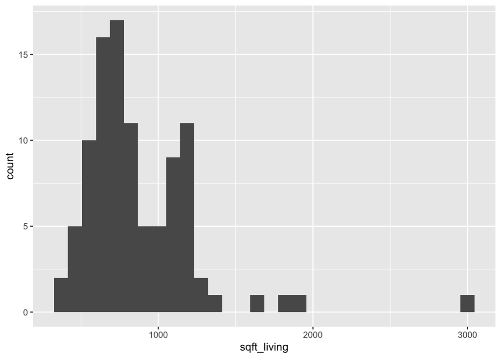

```r
ggplot(data = TrainData_B1)+
  geom_histogram(
    aes(
      x= sqft_living
    )
  )
```

```r
B1_living_limits <- list(
  quantile(
    TrainData_B1$sqft_living,
    .25
    ) - ( 1.5*IQR(TrainData_B1$sqft_living) ),
  quantile(
    TrainData_B1$sqft_living,
    .75) + (1.5*IQR(TrainData_B1$sqft_living) )
  )


TrainData_B1 <- TrainData_B1 %>%
  filter(
    sqft_living >= B1_living_limits[1] &
      sqft_living <= B1_living_limits[2])
```

We will lose 3 observations that could be severely impacting our model. Now lets rerun the regression model:

```r
B1_Reg_model <- lm( price ~ sqft_living + Seattle + log_sqft_lot + peak_volume_season + basement,
                      data = TrainData_B1
)
summary(B1_Reg_model)
```

```
##
## Call:
## lm(formula = price ~ sqft_living + Seattle + log_sqft_lot + peak_volume_season +
##     basement, data = TrainData_B1)
##
## Residuals:
##     Min      1Q  Median      3Q     Max
## -212623  -66704    1178   63260  273031
##
## Coefficients:
##                          Estimate Std. Error t value Pr(>|t|)
## (Intercept)            -196038.40  140276.14  -1.398    0.166
## sqft_living                262.47      43.55   6.027 3.71e-08 ***
## SeattleTrue             140775.21   29638.56   4.750 7.76e-06 ***
## log_sqft_lot             22721.82   13969.72   1.627    0.107
## peak_volume_seasonTrue  -20986.48   22122.08  -0.949    0.345
## basementTrue            -38010.95   34655.53  -1.097    0.276
## ---
## Signif. codes:  0 '***' 0.001 '**' 0.01 '*' 0.05 '.' 0.1 ' ' 1
##
## Residual standard error: 101100 on 89 degrees of freedom
## Multiple R-squared:  0.4118, Adjusted R-squared:  0.3788
## F-statistic: 12.46 on 5 and 89 DF,  p-value: 3.565e-09
```

```r
vif(B1_Reg_model)
```

```
##        sqft_living            Seattle       log_sqft_lot peak_volume_season
##           1.178998           1.762440           1.913832           1.134936
##           basement
##           1.317249
```

```r
bptest(B1_Reg_model)
```

```
##
##  studentized Breusch-Pagan test
##
## data:  B1_Reg_model
## BP = 2.4112, df = 5, p-value = 0.7898
```

```r
gvlma(B1_Reg_model)
```

```
##
## Call:
## lm(formula = price ~ sqft_living + Seattle + log_sqft_lot + peak_volume_season +
##     basement, data = TrainData_B1)
##
## Coefficients:
##            (Intercept)             sqft_living             SeattleTrue
##              -196038.4                   262.5                140775.2
##           log_sqft_lot  peak_volume_seasonTrue            basementTrue
##                22721.8                -20986.5                -38010.9
##
##
## ASSESSMENT OF THE LINEAR MODEL ASSUMPTIONS
## USING THE GLOBAL TEST ON 4 DEGREES-OF-FREEDOM:
## Level of Significance =  0.05
##
## Call:
##  gvlma(x = B1_Reg_model)
##
##                     Value p-value                   Decision
## Global Stat        6.1706 0.18677    Assumptions acceptable.
## Skewness           0.1723 0.67808    Assumptions acceptable.
## Kurtosis           0.1508 0.69780    Assumptions acceptable.
## Link Function      5.7122 0.01685 Assumptions NOT satisfied!
## Heteroscedasticity 0.1353 0.71297    Assumptions acceptable.
```

This model is as accurate and efficient as I can get.

```r
B1_train_predictions <- predict(B1_Reg_model,
                                TrainData_B1[,
                                             -c(16)])

accuracy(B1_train_predictions,
         TrainData_B1$price)
```

```
##                    ME     RMSE      MAE       MPE     MAPE
## Test set 1.035484e-10 97901.34 78256.94 -15.80493 35.73164
```

Overall, the model is not great at predicting, and this seems to be the best model I can produce for 1 bedrooms. This doesn’t mean the overall model will lose any efficiency. At the end of the day, I expect an the accuracy of the segmented regression model to be higher than that of my simple linear regression model.

```r
rm(TrainData_B1,
   B1_train_predictions)
```

### Segment 2-Bedroom

```r
TrainData_B2 <- TrainData %>%
  filter(bedrooms == "2")
str(TrainData_B2)
```

```
## 'data.frame':    1337 obs. of  16 variables:
##  $ sqft_living       : num  1010 850 900 920 1010 1660 1590 1140 2380 1340 ...
##  $ sqft_above        : num  1010 850 900 920 1010 1660 1320 1140 2380 1120 ...
##  $ bathrooms         : num  1 1 1 1 1 1.75 1.75 1 2.5 1.5 ...
##  $ floors            : num  1 1 1 1 1 2 1.5 1 1 2 ...
##  $ sqft_basement     : num  0 0 0 0 0 0 270 0 0 220 ...
##  $ view              : num  0 0 0 0 0 0 3 0 0 0 ...
##  $ ratio_sqft_above  : num  1 1 1 1 1 ...
##  $ log_sqft_lot      : num  8.37 8.09 8.52 8.68 8.29 ...
##  $ bedrooms          : Factor w/ 5 levels "1","2","3","4",..: 2 2 2 2 2 2 2 2 2 2 ...
##  $ renovated         : Factor w/ 2 levels "False","True": 1 1 1 1 1 2 1 1 1 1 ...
##  $ waterfront        : Factor w/ 2 levels "0","1": 1 1 1 1 1 1 1 1 1 1 ...
##  $ peak_volume_season: Factor w/ 2 levels "False","True": 2 1 2 1 2 2 2 2 2 2 ...
##  $ first_view_sale   : Factor w/ 2 levels "False","True": 2 2 2 2 2 2 1 2 2 2 ...
##  $ Seattle           : Factor w/ 2 levels "False","True": 2 2 2 1 2 2 2 2 1 2 ...
##  $ basement          : Factor w/ 2 levels "False","True": 1 1 1 1 1 1 2 1 1 2 ...
##  $ price             : num  501000 389000 553000 156000 337000 ...
```

```r
B2_Reg_model <- lm( price ~
                      sqft_living + Seattle + bathrooms +
                      sqft_basement + floors + first_view_sale ,
                    data = TrainData_B2
)
summary(B2_Reg_model)
```

```
##
## Call:
## lm(formula = price ~ sqft_living + Seattle + bathrooms + sqft_basement +
##     floors + first_view_sale, data = TrainData_B2)
##
## Residuals:
##     Min      1Q  Median      3Q     Max
## -387586  -81387    -415   68072  594980
##
## Coefficients:
##                       Estimate Std. Error t value Pr(>|t|)
## (Intercept)          142968.73   20818.47   6.867 1.00e-11 ***
## sqft_living             224.31      12.49  17.954  < 2e-16 ***
## SeattleTrue          127238.48    7720.80  16.480  < 2e-16 ***
## bathrooms             26889.51    9351.71   2.875  0.00410 **
## sqft_basement           -94.84      18.21  -5.207 2.23e-07 ***
## floors               -24821.92    8187.93  -3.032  0.00248 **
## first_view_saleTrue -106175.61   14529.31  -7.308 4.67e-13 ***
## ---
## Signif. codes:  0 '***' 0.001 '**' 0.01 '*' 0.05 '.' 0.1 ' ' 1
##
## Residual standard error: 126200 on 1330 degrees of freedom
## Multiple R-squared:  0.3999, Adjusted R-squared:  0.3972
## F-statistic: 147.7 on 6 and 1330 DF,  p-value: < 2.2e-16
```

```r
vif(B2_Reg_model)
```

```
##     sqft_living         Seattle       bathrooms   sqft_basement          floors
##        2.259453        1.139497        2.011553        1.804975        1.644743
## first_view_sale
##        1.066453
```

```r
bptest(B2_Reg_model)
```

```
##
##  studentized Breusch-Pagan test
##
## data:  B2_Reg_model
## BP = 74.739, df = 6, p-value = 4.345e-14
```

```r
gvlma(B2_Reg_model)
```

```
##
## Call:
## lm(formula = price ~ sqft_living + Seattle + bathrooms + sqft_basement +
##     floors + first_view_sale, data = TrainData_B2)
##
## Coefficients:
##         (Intercept)          sqft_living          SeattleTrue
##           142968.73               224.31            127238.48
##           bathrooms        sqft_basement               floors
##            26889.51               -94.84            -24821.92
## first_view_saleTrue
##          -106175.61
##
##
## ASSESSMENT OF THE LINEAR MODEL ASSUMPTIONS
## USING THE GLOBAL TEST ON 4 DEGREES-OF-FREEDOM:
## Level of Significance =  0.05
##
## Call:
##  gvlma(x = B2_Reg_model)
##
##                       Value p-value                   Decision
## Global Stat        175.9258 0.00000 Assumptions NOT satisfied!
## Skewness            74.5877 0.00000 Assumptions NOT satisfied!
## Kurtosis            93.2732 0.00000 Assumptions NOT satisfied!
## Link Function        7.1397 0.00754 Assumptions NOT satisfied!
## Heteroscedasticity   0.9252 0.33611    Assumptions acceptable.
```

Skewness is the main issue, then I will address the bptest that shows heteroskedasticity.

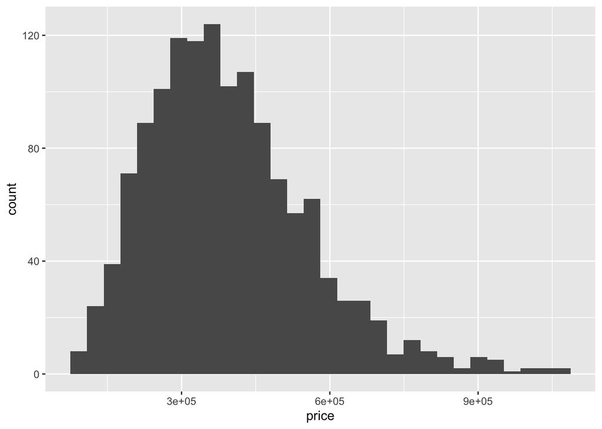

```r
ggplot(data = TrainData_B2) +
  geom_histogram(
    aes(
      x=price
    )
  )
```

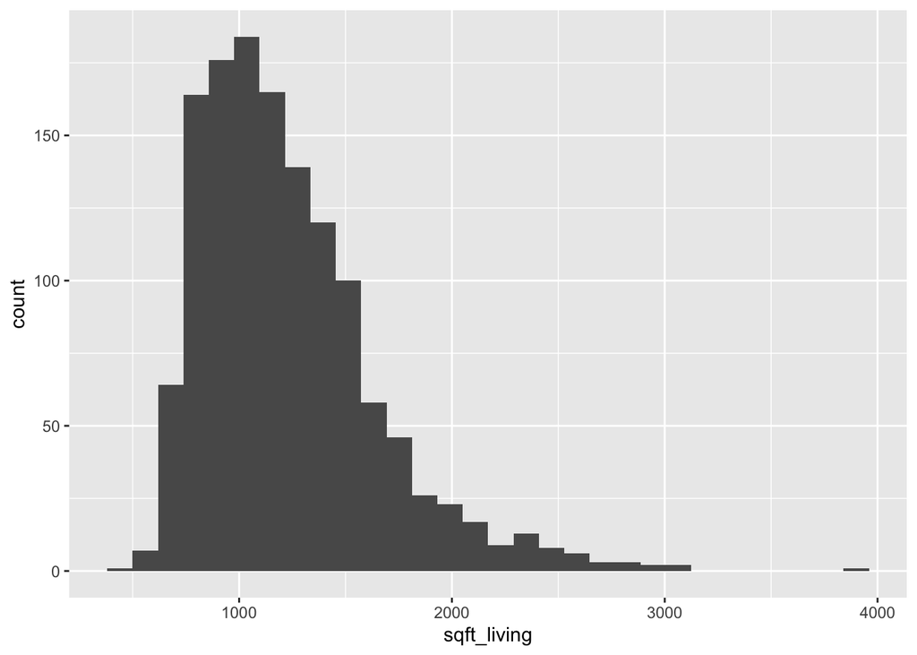

```r
ggplot(data = TrainData_B2) +
  geom_histogram(
    aes(
      x=sqft_living
    )
  )
```

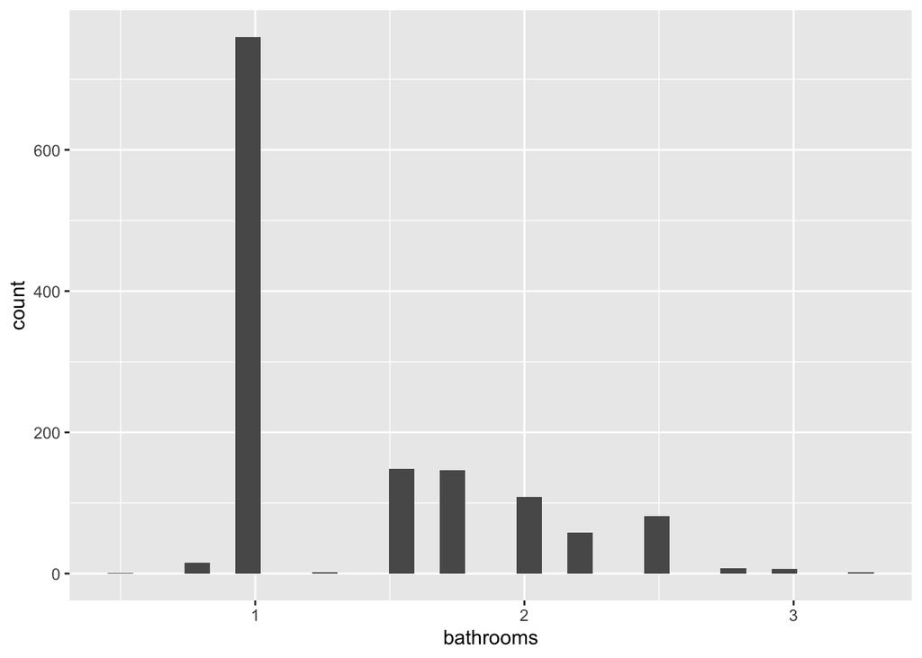

```r
ggplot(data = TrainData_B2) +
  geom_histogram(
    aes(
      x=bathrooms
    )
  )
```

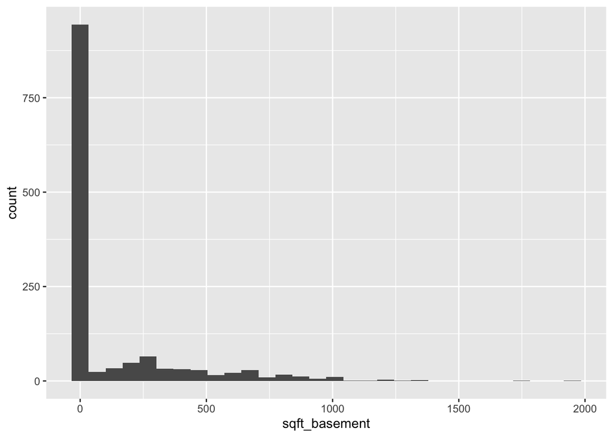

```r
ggplot(data = TrainData_B2) +
  geom_histogram(
    aes(
      x=sqft_basement
    )
  )
```

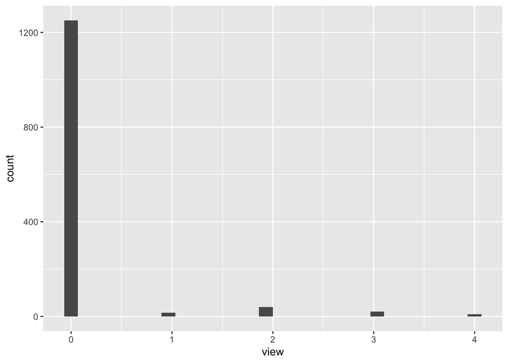

```r
ggplot(data = TrainData_B2) +
  geom_histogram(
    aes(
      x=view
    )
  )
```

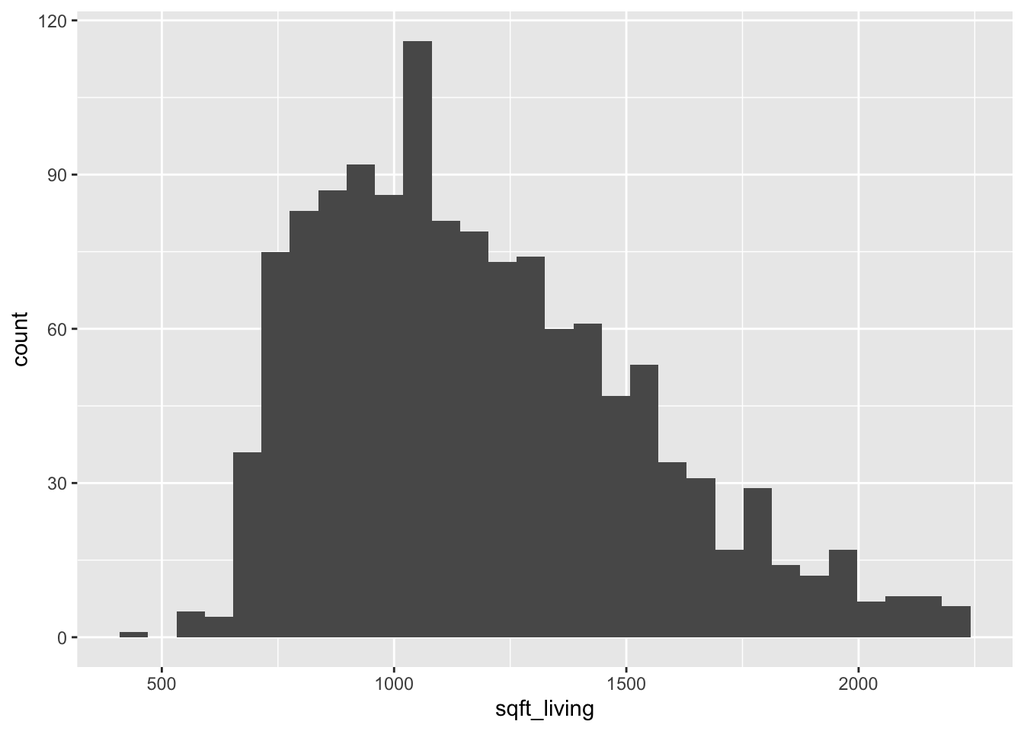

```r
B2_sqft_living_cutoffs <- list(quantile(TrainData_B2$sqft_living,
                                        .25) - (1.5*IQR(TrainData_B2$sqft_living)),
                               quantile(TrainData_B2$sqft_living,
                                        .75) + (1.5*IQR(TrainData_B2$sqft_living)))

TrainData_B2 <- TrainData_B2 %>%
  filter(
    sqft_living >= B2_sqft_living_cutoffs[1] &
      sqft_living <= B2_sqft_living_cutoffs[2]
    )
ggplot(data = TrainData_B2) +
  geom_histogram(
    aes(
      x=sqft_living
    )
  )
```

I removed the skewness in square footage by capping it to 2220. This results in 3% dataloss which is acceptable.

Rerun the regression:

```r
B2_Reg_model <- lm( price ~
                      sqft_living + Seattle + bathrooms +
                      sqft_basement + floors + first_view_sale ,
                    data = TrainData_B2
)
summary(B2_Reg_model)
```

```
##
## Call:
## lm(formula = price ~ sqft_living + Seattle + bathrooms + sqft_basement +
##     floors + first_view_sale, data = TrainData_B2)
##
## Residuals:
##     Min      1Q  Median      3Q     Max
## -372403  -83024   -2684   67219  600233
##
## Coefficients:
##                       Estimate Std. Error t value Pr(>|t|)
## (Intercept)          164783.56   21855.94   7.540 8.86e-14 ***
## sqft_living             207.01      14.27  14.507  < 2e-16 ***
## SeattleTrue          124375.50    7649.55  16.259  < 2e-16 ***
## bathrooms             16993.22    9454.09   1.797 0.072499 .
## sqft_basement           -68.83      19.85  -3.467 0.000544 ***
## floors               -16840.23    8269.65  -2.036 0.041915 *
## first_view_saleTrue -106660.57   14938.35  -7.140 1.55e-12 ***
## ---
## Signif. codes:  0 '***' 0.001 '**' 0.01 '*' 0.05 '.' 0.1 ' ' 1
##
## Residual standard error: 122900 on 1289 degrees of freedom
## Multiple R-squared:  0.3414, Adjusted R-squared:  0.3383
## F-statistic: 111.4 on 6 and 1289 DF,  p-value: < 2.2e-16
```

```r
vif(B2_Reg_model)
```

```
##     sqft_living         Seattle       bathrooms   sqft_basement          floors
##        2.055366        1.125227        1.939769        1.763390        1.708125
## first_view_sale
##        1.030267
```

```r
bptest(B2_Reg_model)
```

```
##
##  studentized Breusch-Pagan test
##
## data:  B2_Reg_model
## BP = 49.245, df = 6, p-value = 6.658e-09
```

```r
gvlma(B2_Reg_model)
```

```
##
## Call:
## lm(formula = price ~ sqft_living + Seattle + bathrooms + sqft_basement +
##     floors + first_view_sale, data = TrainData_B2)
##
## Coefficients:
##         (Intercept)          sqft_living          SeattleTrue
##           164783.56               207.01            124375.50
##           bathrooms        sqft_basement               floors
##            16993.22               -68.83            -16840.23
## first_view_saleTrue
##          -106660.57
##
##
## ASSESSMENT OF THE LINEAR MODEL ASSUMPTIONS
## USING THE GLOBAL TEST ON 4 DEGREES-OF-FREEDOM:
## Level of Significance =  0.05
##
## Call:
##  gvlma(x = B2_Reg_model)
##
##                      Value p-value                   Decision
## Global Stat        193.169  0.0000 Assumptions NOT satisfied!
## Skewness            87.949  0.0000 Assumptions NOT satisfied!
## Kurtosis           102.968  0.0000 Assumptions NOT satisfied!
## Link Function        1.159  0.2818    Assumptions acceptable.
## Heteroscedasticity   1.093  0.2958    Assumptions acceptable.
```

Heteroskedasticity may be present I’ll readress that before addressing skewness anymore:

```r
model_of_weights <- lm(abs(B2_Reg_model$residuals) ~ B2_Reg_model$fitted.values)

weight <- 1/(model_of_weights$fitted.values)^2

B2_Reg_model_weighted <- lm(
  formula = price ~
    sqft_living + Seattle + bathrooms +
    sqft_basement + floors + first_view_sale,
  data = TrainData_B2,
  weights = weight
)
summary(B2_Reg_model_weighted)
```

```
##
## Call:
## lm(formula = price ~ sqft_living + Seattle + bathrooms + sqft_basement +
##     floors + first_view_sale, data = TrainData_B2, weights = weight)
##
## Weighted Residuals:
##     Min      1Q  Median      3Q     Max
## -3.1699 -0.9073 -0.0339  0.7228  7.4630
##
## Coefficients:
##                       Estimate Std. Error t value Pr(>|t|)
## (Intercept)          168938.29   22748.20   7.426 2.02e-13 ***
## sqft_living             207.75      14.71  14.125  < 2e-16 ***
## SeattleTrue          120540.37    7001.01  17.218  < 2e-16 ***
## bathrooms             14311.31    9755.45   1.467  0.14262
## sqft_basement           -63.74      21.47  -2.970  0.00304 **
## floors               -16105.25    8387.33  -1.920  0.05505 .
## first_view_saleTrue -107140.09   17380.64  -6.164 9.45e-10 ***
## ---
## Signif. codes:  0 '***' 0.001 '**' 0.01 '*' 0.05 '.' 0.1 ' ' 1
##
## Residual standard error: 1.309 on 1289 degrees of freedom
## Multiple R-squared:  0.3447, Adjusted R-squared:  0.3416
## F-statistic:   113 on 6 and 1289 DF,  p-value: < 2.2e-16
```

```r
vif(B2_Reg_model_weighted)
```

```
##     sqft_living         Seattle       bathrooms   sqft_basement          floors
##        2.016834        1.114769        1.968746        1.666759        1.678948
## first_view_sale
##        1.017907
```

```r
bptest(B2_Reg_model_weighted)
```

```
##
##  studentized Breusch-Pagan test
##
## data:  B2_Reg_model_weighted
## BP = 3.5961e-08, df = 6, p-value = 1
```

```r
gvlma(B2_Reg_model_weighted)
```

```
##
## Call:
## lm(formula = price ~ sqft_living + Seattle + bathrooms + sqft_basement +
##     floors + first_view_sale, data = TrainData_B2, weights = weight)
##
## Coefficients:
##         (Intercept)          sqft_living          SeattleTrue
##           168938.29               207.75            120540.37
##           bathrooms        sqft_basement               floors
##            14311.31               -63.74            -16105.25
## first_view_saleTrue
##          -107140.09
##
##
## ASSESSMENT OF THE LINEAR MODEL ASSUMPTIONS
## USING THE GLOBAL TEST ON 4 DEGREES-OF-FREEDOM:
## Level of Significance =  0.05
##
## Call:
##  gvlma(x = B2_Reg_model_weighted)
##
##                       Value p-value                   Decision
## Global Stat        187.4467  0.0000 Assumptions NOT satisfied!
## Skewness            86.8180  0.0000 Assumptions NOT satisfied!
## Kurtosis            98.9680  0.0000 Assumptions NOT satisfied!
## Link Function        0.6755  0.4112    Assumptions acceptable.
## Heteroscedasticity   0.9852  0.3209    Assumptions acceptable.
```

I lost a lot of accuracy by removing the “outliers” and it didn’t remove the skewness, we will add it back and continue while understanding the model is violating certain assumptions of a linear regression. This makes sense because many of these relationships are not linear. I am reverting back to containing all datapoints and continuing with the weighted model which removes the heteroskedasticity.

```r
TrainData_B2 <- TrainData %>%
  filter(bedrooms == "2")
str(TrainData_B2)
```

```
## 'data.frame':    1337 obs. of  16 variables:
##  $ sqft_living       : num  1010 850 900 920 1010 1660 1590 1140 2380 1340 ...
##  $ sqft_above        : num  1010 850 900 920 1010 1660 1320 1140 2380 1120 ...
##  $ bathrooms         : num  1 1 1 1 1 1.75 1.75 1 2.5 1.5 ...
##  $ floors            : num  1 1 1 1 1 2 1.5 1 1 2 ...
##  $ sqft_basement     : num  0 0 0 0 0 0 270 0 0 220 ...
##  $ view              : num  0 0 0 0 0 0 3 0 0 0 ...
##  $ ratio_sqft_above  : num  1 1 1 1 1 ...
##  $ log_sqft_lot      : num  8.37 8.09 8.52 8.68 8.29 ...
##  $ bedrooms          : Factor w/ 5 levels "1","2","3","4",..: 2 2 2 2 2 2 2 2 2 2 ...
##  $ renovated         : Factor w/ 2 levels "False","True": 1 1 1 1 1 2 1 1 1 1 ...
##  $ waterfront        : Factor w/ 2 levels "0","1": 1 1 1 1 1 1 1 1 1 1 ...
##  $ peak_volume_season: Factor w/ 2 levels "False","True": 2 1 2 1 2 2 2 2 2 2 ...
##  $ first_view_sale   : Factor w/ 2 levels "False","True": 2 2 2 2 2 2 1 2 2 2 ...
##  $ Seattle           : Factor w/ 2 levels "False","True": 2 2 2 1 2 2 2 2 1 2 ...
##  $ basement          : Factor w/ 2 levels "False","True": 1 1 1 1 1 1 2 1 1 2 ...
##  $ price             : num  501000 389000 553000 156000 337000 ...
```

```r
B2_Reg_model <- lm( price ~
                      sqft_living + Seattle + bathrooms +
                      sqft_basement + floors + first_view_sale ,
                    data = TrainData_B2
)

model_of_weights <- lm(abs(B2_Reg_model$residuals) ~ B2_Reg_model$fitted.values)

weight <- 1/(model_of_weights$fitted.values)^2

B2_Reg_model_weighted <- lm(
  formula = price ~
    sqft_living + Seattle + bathrooms +
    sqft_basement + floors + first_view_sale,
  data = TrainData_B2,
  weights = weight
)
summary(B2_Reg_model_weighted)
```

```
##
## Call:
## lm(formula = price ~ sqft_living + Seattle + bathrooms + sqft_basement +
##     floors + first_view_sale, data = TrainData_B2, weights = weight)
##
## Weighted Residuals:
##     Min      1Q  Median      3Q     Max
## -3.1437 -0.9074 -0.0199  0.7157  7.3445
##
## Coefficients:
##                       Estimate Std. Error t value Pr(>|t|)
## (Intercept)          156471.38   21884.77   7.150 1.43e-12 ***
## sqft_living             218.41      13.50  16.176  < 2e-16 ***
## SeattleTrue          121249.53    6927.70  17.502  < 2e-16 ***
## bathrooms             19083.93    9686.77   1.970   0.0490 *
## sqft_basement           -80.78      20.36  -3.968 7.65e-05 ***
## floors               -20163.82    8263.83  -2.440   0.0148 *
## first_view_saleTrue -105833.74   17000.41  -6.225 6.43e-10 ***
## ---
## Signif. codes:  0 '***' 0.001 '**' 0.01 '*' 0.05 '.' 0.1 ' ' 1
##
## Residual standard error: 1.307 on 1330 degrees of freedom
## Multiple R-squared:  0.3766, Adjusted R-squared:  0.3738
## F-statistic: 133.9 on 6 and 1330 DF,  p-value: < 2.2e-16
```

```r
vif(B2_Reg_model_weighted)
```

```
##     sqft_living         Seattle       bathrooms   sqft_basement          floors
##        2.134419        1.113087        2.010763        1.705020        1.644948
## first_view_sale
##        1.034763
```

```r
bptest(B2_Reg_model_weighted)
```

```
##
##  studentized Breusch-Pagan test
##
## data:  B2_Reg_model_weighted
## BP = 3.5857e-08, df = 6, p-value = 1
```

```r
gvlma(B2_Reg_model_weighted)
```

```
##
## Call:
## lm(formula = price ~ sqft_living + Seattle + bathrooms + sqft_basement +
##     floors + first_view_sale, data = TrainData_B2, weights = weight)
##
## Coefficients:
##         (Intercept)          sqft_living          SeattleTrue
##           156471.38               218.41            121249.53
##           bathrooms        sqft_basement               floors
##            19083.93               -80.78            -20163.82
## first_view_saleTrue
##          -105833.74
##
##
## ASSESSMENT OF THE LINEAR MODEL ASSUMPTIONS
## USING THE GLOBAL TEST ON 4 DEGREES-OF-FREEDOM:
## Level of Significance =  0.05
##
## Call:
##  gvlma(x = B2_Reg_model_weighted)
##
##                       Value p-value                   Decision
## Global Stat        177.1200 0.00000 Assumptions NOT satisfied!
## Skewness            79.8021 0.00000 Assumptions NOT satisfied!
## Kurtosis            89.6245 0.00000 Assumptions NOT satisfied!
## Link Function        6.9871 0.00821 Assumptions NOT satisfied!
## Heteroscedasticity   0.7064 0.40065    Assumptions acceptable.
```

```r
B2_train_predictions <- predict(B2_Reg_model_weighted,
                                TrainData_B2[,
                                             -c(16)])

accuracy(B2_train_predictions,
         TrainData_B2$price)
```

```
##                ME     RMSE      MAE       MPE     MAPE
## Test set 228.5064 125963.5 96478.68 -11.72888 29.18529
```

Okay, this model is getting closer to beating the simpler linear regression model that didn’t segment based on number of bedrooms.

```r
rm(TrainData_B2,
   model_of_weights,
   B2_sqft_living_cutoffs,
   B2_Reg_model,
   B2_train_predictions,
   weight)
```

### Segment 3-Bedroom

```r
TrainData_B3 <- TrainData %>%
  filter(bedrooms == "3")
str(TrainData_B3)
```

```
## 'data.frame':    4688 obs. of  16 variables:
##  $ sqft_living       : num  1740 1660 900 1850 1120 2190 1260 780 2710 1820 ...
##  $ sqft_above        : num  1210 1530 900 1150 1120 2190 1260 780 1650 1820 ...
##  $ bathrooms         : num  2.25 2.5 1 1.75 1 2.5 2.5 1 3.5 2.25 ...
##  $ floors            : num  1 3 1 1 1 2 2 1 2 1 ...
##  $ sqft_basement     : num  530 130 0 700 0 0 0 0 1060 0 ...
##  $ view              : num  0 1 0 0 0 0 0 0 0 0 ...
##  $ ratio_sqft_above  : num  0.695 0.922 1 0.622 1 ...
##  $ log_sqft_lot      : num  8.61 6.99 8.93 7.94 8.79 ...
##  $ bedrooms          : Factor w/ 5 levels "1","2","3","4",..: 3 3 3 3 3 3 3 3 3 3 ...
##  $ renovated         : Factor w/ 2 levels "False","True": 1 1 1 1 1 1 1 1 1 1 ...
##  $ waterfront        : Factor w/ 2 levels "0","1": 1 1 1 1 1 1 1 1 1 1 ...
##  $ peak_volume_season: Factor w/ 2 levels "False","True": 1 2 2 2 2 2 2 1 1 1 ...
##  $ first_view_sale   : Factor w/ 2 levels "False","True": 2 1 2 2 2 2 2 2 2 2 ...
##  $ Seattle           : Factor w/ 2 levels "False","True": 1 2 1 2 2 1 1 2 1 1 ...
##  $ basement          : Factor w/ 2 levels "False","True": 2 2 1 2 1 1 1 1 2 1 ...
##  $ price             : num  266500 729500 201000 580000 549995 ...
```

```r
B3_Reg_model <- lm(
  price ~
    sqft_living + bathrooms + sqft_basement + view +
    renovated + peak_volume_season + Seattle ,
  data = TrainData_B3
)
summary(B3_Reg_model)
```

```
##
## Call:
## lm(formula = price ~ sqft_living + bathrooms + sqft_basement +
##     view + renovated + peak_volume_season + Seattle, data = TrainData_B3)
##
## Residuals:
##     Min      1Q  Median      3Q     Max
## -447198  -98451  -18183   86358  759635
##
## Coefficients:
##                          Estimate Std. Error t value Pr(>|t|)
## (Intercept)             26059.884   8160.112   3.194  0.00141 **
## sqft_living               187.735      4.870  38.551  < 2e-16 ***
## bathrooms               18125.983   4051.917   4.473 7.88e-06 ***
## sqft_basement             -40.304      6.824  -5.906 3.76e-09 ***
## view                    29075.567   3733.697   7.787 8.37e-15 ***
## renovatedTrue           50685.647  10866.678   4.664 3.18e-06 ***
## peak_volume_seasonTrue  10052.366   4097.576   2.453  0.01419 *
## SeattleTrue            132579.370   4593.088  28.865  < 2e-16 ***
## ---
## Signif. codes:  0 '***' 0.001 '**' 0.01 '*' 0.05 '.' 0.1 ' ' 1
##
## Residual standard error: 140100 on 4680 degrees of freedom
## Multiple R-squared:  0.4393, Adjusted R-squared:  0.4385
## F-statistic: 523.9 on 7 and 4680 DF,  p-value: < 2.2e-16
```

```r
vif(B3_Reg_model)
```

```
##        sqft_living          bathrooms      sqft_basement               view
##           1.879154           1.524374           1.279536           1.068650
##          renovated peak_volume_season            Seattle
##           1.008339           1.002494           1.111535
```

```r
bptest(B3_Reg_model)
```

```
##
##  studentized Breusch-Pagan test
##
## data:  B3_Reg_model
## BP = 152.55, df = 7, p-value < 2.2e-16
```

```r
gvlma(B3_Reg_model)
```

```
##
## Call:
## lm(formula = price ~ sqft_living + bathrooms + sqft_basement +
##     view + renovated + peak_volume_season + Seattle, data = TrainData_B3)
##
## Coefficients:
##            (Intercept)             sqft_living               bathrooms
##                26059.9                   187.7                 18126.0
##          sqft_basement                    view           renovatedTrue
##                  -40.3                 29075.6                 50685.6
## peak_volume_seasonTrue             SeattleTrue
##                10052.4                132579.4
##
##
## ASSESSMENT OF THE LINEAR MODEL ASSUMPTIONS
## USING THE GLOBAL TEST ON 4 DEGREES-OF-FREEDOM:
## Level of Significance =  0.05
##
## Call:
##  gvlma(x = B3_Reg_model)
##
##                       Value p-value                   Decision
## Global Stat        728.6481  0.0000 Assumptions NOT satisfied!
## Skewness           417.1547  0.0000 Assumptions NOT satisfied!
## Kurtosis           309.0116  0.0000 Assumptions NOT satisfied!
## Link Function        2.2581  0.1329    Assumptions acceptable.
## Heteroscedasticity   0.2238  0.6362    Assumptions acceptable.
```

```r
summary(TrainData_B3$sqft_living)
```

```
##    Min. 1st Qu.  Median    Mean 3rd Qu.    Max.
##     660    1370    1670    1776    2080    4720
```

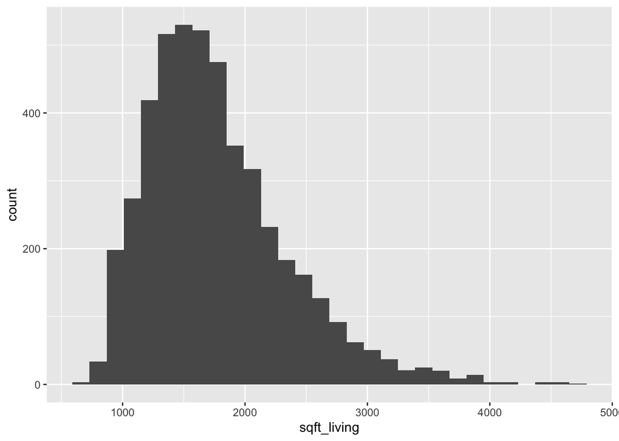

```r
ggplot(data = TrainData_B3) +
  geom_histogram(
    aes(
      x=sqft_living
    )
  )
```

Remove skewness in sqft_living:

```r
B3_living_limits <- list(
  quantile(
    TrainData_B3$sqft_living,
    .25) - ( 1.5*IQR(TrainData_B3$sqft_living) ),
  quantile(
    TrainData_B3$sqft_living,
    .75) + ( 1.5*IQR(TrainData_B3$sqft_living) )
  )

TrainData_B3 <- TrainData_B3 %>%
  filter(
    sqft_living >= B3_living_limits[1] &
      sqft_living <= B3_living_limits[2]
  )
```

Less than a 3% loss in data which is acceptable.

```r
B3_Reg_model <- lm(
  price ~
    sqft_living + bathrooms + sqft_basement + view +
    renovated + peak_volume_season + Seattle ,
  data = TrainData_B3
)
summary(B3_Reg_model)
```

```
##
## Call:
## lm(formula = price ~ sqft_living + bathrooms + sqft_basement +
##     view + renovated + peak_volume_season + Seattle, data = TrainData_B3)
##
## Residuals:
##     Min      1Q  Median      3Q     Max
## -423071  -97174  -18028   86168  760541
##
## Coefficients:
##                          Estimate Std. Error t value Pr(>|t|)
## (Intercept)             22529.876   8834.568   2.550 0.010799 *
## sqft_living               193.324      5.611  34.452  < 2e-16 ***
## bathrooms               14917.669   4118.422   3.622 0.000295 ***
## sqft_basement             -37.961      7.196  -5.275 1.39e-07 ***
## view                    32854.480   3883.957   8.459  < 2e-16 ***
## renovatedTrue           56977.439  11174.725   5.099 3.56e-07 ***
## peak_volume_seasonTrue   9740.277   4132.268   2.357 0.018459 *
## SeattleTrue            131500.888   4608.138  28.537  < 2e-16 ***
## ---
## Signif. codes:  0 '***' 0.001 '**' 0.01 '*' 0.05 '.' 0.1 ' ' 1
##
## Residual standard error: 139300 on 4548 degrees of freedom
## Multiple R-squared:  0.3991, Adjusted R-squared:  0.3982
## F-statistic: 431.6 on 7 and 4548 DF,  p-value: < 2.2e-16
```

```r
vif(B3_Reg_model)
```

```
##        sqft_living          bathrooms      sqft_basement               view
##           1.810497           1.481594           1.278474           1.055953
##          renovated peak_volume_season            Seattle
##           1.005916           1.002421           1.108579
```

```r
bptest(B3_Reg_model)
```

```
##
##  studentized Breusch-Pagan test
##
## data:  B3_Reg_model
## BP = 168.01, df = 7, p-value < 2.2e-16
```

```r
gvlma(B3_Reg_model)
```

```
##
## Call:
## lm(formula = price ~ sqft_living + bathrooms + sqft_basement +
##     view + renovated + peak_volume_season + Seattle, data = TrainData_B3)
##
## Coefficients:
##            (Intercept)             sqft_living               bathrooms
##               22529.88                  193.32                14917.67
##          sqft_basement                    view           renovatedTrue
##                 -37.96                32854.48                56977.44
## peak_volume_seasonTrue             SeattleTrue
##                9740.28               131500.89
##
##
## ASSESSMENT OF THE LINEAR MODEL ASSUMPTIONS
## USING THE GLOBAL TEST ON 4 DEGREES-OF-FREEDOM:
## Level of Significance =  0.05
##
## Call:
##  gvlma(x = B3_Reg_model)
##
##                        Value   p-value                   Decision
## Global Stat        7.658e+02 0.000e+00 Assumptions NOT satisfied!
## Skewness           4.204e+02 0.000e+00 Assumptions NOT satisfied!
## Kurtosis           3.264e+02 0.000e+00 Assumptions NOT satisfied!
## Link Function      1.896e+01 1.336e-05 Assumptions NOT satisfied!
## Heteroscedasticity 7.057e-04 9.788e-01    Assumptions acceptable.
```

It didn’t remove skewness, and it hurts the accuracy, so I will keep the outliers.

```r
TrainData_B3 <- TrainData %>%
  filter(bedrooms == "3")
str(TrainData_B3)
```

```
## 'data.frame':    4688 obs. of  16 variables:
##  $ sqft_living       : num  1740 1660 900 1850 1120 2190 1260 780 2710 1820 ...
##  $ sqft_above        : num  1210 1530 900 1150 1120 2190 1260 780 1650 1820 ...
##  $ bathrooms         : num  2.25 2.5 1 1.75 1 2.5 2.5 1 3.5 2.25 ...
##  $ floors            : num  1 3 1 1 1 2 2 1 2 1 ...
##  $ sqft_basement     : num  530 130 0 700 0 0 0 0 1060 0 ...
##  $ view              : num  0 1 0 0 0 0 0 0 0 0 ...
##  $ ratio_sqft_above  : num  0.695 0.922 1 0.622 1 ...
##  $ log_sqft_lot      : num  8.61 6.99 8.93 7.94 8.79 ...
##  $ bedrooms          : Factor w/ 5 levels "1","2","3","4",..: 3 3 3 3 3 3 3 3 3 3 ...
##  $ renovated         : Factor w/ 2 levels "False","True": 1 1 1 1 1 1 1 1 1 1 ...
##  $ waterfront        : Factor w/ 2 levels "0","1": 1 1 1 1 1 1 1 1 1 1 ...
##  $ peak_volume_season: Factor w/ 2 levels "False","True": 1 2 2 2 2 2 2 1 1 1 ...
##  $ first_view_sale   : Factor w/ 2 levels "False","True": 2 1 2 2 2 2 2 2 2 2 ...
##  $ Seattle           : Factor w/ 2 levels "False","True": 1 2 1 2 2 1 1 2 1 1 ...
##  $ basement          : Factor w/ 2 levels "False","True": 2 2 1 2 1 1 1 1 2 1 ...
##  $ price             : num  266500 729500 201000 580000 549995 ...
```

```r
B3_Reg_model <- lm(
  price ~
    sqft_living + bathrooms + sqft_basement + view +
    renovated + peak_volume_season + Seattle ,
  data = TrainData_B3
)
summary(B3_Reg_model)
```

```
##
## Call:
## lm(formula = price ~ sqft_living + bathrooms + sqft_basement +
##     view + renovated + peak_volume_season + Seattle, data = TrainData_B3)
##
## Residuals:
##     Min      1Q  Median      3Q     Max
## -447198  -98451  -18183   86358  759635
##
## Coefficients:
##                          Estimate Std. Error t value Pr(>|t|)
## (Intercept)             26059.884   8160.112   3.194  0.00141 **
## sqft_living               187.735      4.870  38.551  < 2e-16 ***
## bathrooms               18125.983   4051.917   4.473 7.88e-06 ***
## sqft_basement             -40.304      6.824  -5.906 3.76e-09 ***
## view                    29075.567   3733.697   7.787 8.37e-15 ***
## renovatedTrue           50685.647  10866.678   4.664 3.18e-06 ***
## peak_volume_seasonTrue  10052.366   4097.576   2.453  0.01419 *
## SeattleTrue            132579.370   4593.088  28.865  < 2e-16 ***
## ---
## Signif. codes:  0 '***' 0.001 '**' 0.01 '*' 0.05 '.' 0.1 ' ' 1
##
## Residual standard error: 140100 on 4680 degrees of freedom
## Multiple R-squared:  0.4393, Adjusted R-squared:  0.4385
## F-statistic: 523.9 on 7 and 4680 DF,  p-value: < 2.2e-16
```

```r
model_of_weights <- lm(abs(B3_Reg_model$residuals) ~ B3_Reg_model$fitted.values)

weight <- 1/(model_of_weights$fitted.values)^2

B3_Reg_model_weighted <- lm(
  formula = price ~
    sqft_living + bathrooms + sqft_basement + view +
    renovated + peak_volume_season + Seattle,
  data = TrainData_B3,
  weights = weight
)
summary(B3_Reg_model_weighted)
```

```
##
## Call:
## lm(formula = price ~ sqft_living + bathrooms + sqft_basement +
##     view + renovated + peak_volume_season + Seattle, data = TrainData_B3,
##     weights = weight)
##
## Weighted Residuals:
##     Min      1Q  Median      3Q     Max
## -2.9545 -0.9503 -0.1746  0.8019  7.9899
##
## Coefficients:
##                          Estimate Std. Error t value Pr(>|t|)
## (Intercept)             37607.184   7624.020   4.933 8.39e-07 ***
## sqft_living               184.788      5.363  34.457  < 2e-16 ***
## bathrooms               15636.190   3996.372   3.913 9.26e-05 ***
## sqft_basement             -38.263      7.344  -5.210 1.97e-07 ***
## view                    31272.868   4454.280   7.021 2.52e-12 ***
## renovatedTrue           52916.284  11614.982   4.556 5.35e-06 ***
## peak_volume_seasonTrue   8721.502   3914.187   2.228   0.0259 *
## SeattleTrue            126962.763   4600.677  27.597  < 2e-16 ***
## ---
## Signif. codes:  0 '***' 0.001 '**' 0.01 '*' 0.05 '.' 0.1 ' ' 1
##
## Residual standard error: 1.268 on 4680 degrees of freedom
## Multiple R-squared:  0.4069, Adjusted R-squared:  0.406
## F-statistic: 458.7 on 7 and 4680 DF,  p-value: < 2.2e-16
```

```r
vif(B3_Reg_model_weighted)
```

```
##        sqft_living          bathrooms      sqft_basement               view
##           1.950138           1.598085           1.293649           1.048077
##          renovated peak_volume_season            Seattle
##           1.004632           1.002970           1.079450
```

```r
bptest(B3_Reg_model_weighted)
```

```
##
##  studentized Breusch-Pagan test
##
## data:  B3_Reg_model_weighted
## BP = 9.1851e-08, df = 7, p-value = 1
```

```r
gvlma(B3_Reg_model_weighted)
```

```
##
## Call:
## lm(formula = price ~ sqft_living + bathrooms + sqft_basement +
##     view + renovated + peak_volume_season + Seattle, data = TrainData_B3,
##     weights = weight)
##
## Coefficients:
##            (Intercept)             sqft_living               bathrooms
##               37607.18                  184.79                15636.19
##          sqft_basement                    view           renovatedTrue
##                 -38.26                31272.87                52916.28
## peak_volume_seasonTrue             SeattleTrue
##                8721.50               126962.76
##
##
## ASSESSMENT OF THE LINEAR MODEL ASSUMPTIONS
## USING THE GLOBAL TEST ON 4 DEGREES-OF-FREEDOM:
## Level of Significance =  0.05
##
## Call:
##  gvlma(x = B3_Reg_model_weighted)
##
##                       Value p-value                   Decision
## Global Stat        732.4412  0.0000 Assumptions NOT satisfied!
## Skewness           433.3250  0.0000 Assumptions NOT satisfied!
## Kurtosis           296.3862  0.0000 Assumptions NOT satisfied!
## Link Function        2.5127  0.1129    Assumptions acceptable.
## Heteroscedasticity   0.2174  0.6411    Assumptions acceptable.
```

Running into similar issues as the last model. This is the best the linear regression can do with the relationships between these variables.

```r
B3_train_predictions <- predict(B3_Reg_model_weighted,
                                TrainData_B3[,
                                             -c(16)])

accuracy(B3_train_predictions,
         TrainData_B3$price)
```

```
##                ME     RMSE      MAE       MPE    MAPE
## Test set 247.0139 140000.1 110196.6 -10.63061 28.4422
```

Again, getting similar results as the simple regression above, but lets follow this through:

```r
rm(TrainData_B3,
   B3_Reg_model,
   B3_living_limits,
   model_of_weights,
   B3_train_predictions,
   weight)
```